# DiffuChannel benchmark: diffusion vs DeepGANnel across all phenotypes

```r
  w <- vapply(runs, length, integer(1))
  A <- vapply(runs, function(x)
    stats::acf(x - mean(x), lag.max = lag_max, plot = FALSE,
               demean = TRUE)$acf[, 1, 1], numeric(lag_max + 1))
  tibble::tibble(lag_n  = seq_len(lag_max + 1),
                 lag_ms = 1000 * (seq_len(lag_max + 1) - 1) / fs,
                 acf    = as.numeric(A %*% w / sum(w)),
                 n_used = sum(w))
}

dwell_times <- function(ideal, fs) {
  r <- rle(as.integer(round(ideal)))
  tibble::tibble(level = r$values, n_sample = r$lengths,
                 dwell_ms = 1000 * r$lengths / fs) |>
    dplyr::mutate(state = ifelse(level == 0, "Closed", "Open"))
}

# Half-amplitude idealiser. Two Gaussians of common width, fitted by EM.
# Hard assignment fails when one level holds 1% of the record: the far tail of
# the crowded level outnumbers the sparse one on its own side of any threshold
# and drags the estimate onto itself. Responsibilities do not have that
# problem. Polarity says which of the two fitted levels is shut.
idealise_half_amplitude <- function(current, unit_pA = NULL, baseline = NULL,
                                    n_levels = 1, polarity = 1) {
  x <- current[is.finite(current)]

  if (is.null(baseline) || is.null(unit_pA)) {
    # Fitting on a regular subsample keeps the knit time sane; a level holding
    # 1% of the record still contributes ~1000 points here.
    xf <- if (length(x) > 1e5) x[seq(1, length(x), length.out = 1e5)] else x

    # Seed outside both bulks, not at the 1st/99th percentile: in a record
    # that is open 99% of the time the 1st percentile is still open. The
    # starting weight is taken from the split at the midpoint rather than set
    # to a half, so the sparse component is not invited to bid for the
    # crowded one.
    mu  <- stats::quantile(xf, c(0.001, 0.999), names = FALSE)
    sg  <- max(stats::mad(xf), .Machine$double.eps^0.5)
    w   <- min(max(mean(xf < mean(mu)), 1e-3), 1 - 1e-3)
    tol <- 1e-8 * sg

    for (i in 1:300) {
      d1 <- stats::dnorm(xf, mu[1], sg) * w
      d2 <- stats::dnorm(xf, mu[2], sg) * (1 - w)
      r  <- d2 / (d1 + d2)
      r[!is.finite(r)] <- 0.5
      s2 <- sum(r); s1 <- sum(1 - r)
      if (s1 < 1 || s2 < 1) break
      new_mu <- c(sum((1 - r) * xf) / s1, sum(r * xf) / s2)
      new_sg <- max(sqrt((sum((1 - r) * (xf - new_mu[1])^2) +
                          sum(r * (xf - new_mu[2])^2)) / length(xf)),
                    .Machine$double.eps^0.5)
      w <- s1 / length(xf)
      done <- max(abs(c(new_mu - mu, new_sg - sg))) < tol
      mu <- new_mu; sg <- new_sg
      if (done) break
    }

    mu   <- sort(mu)
    shut <- if (polarity >= 0) mu[1] else mu[2]
    open <- if (polarity >= 0) mu[2] else mu[1]
    minority <- min(w, 1 - w)

    if (!is.finite(open - shut) || abs(open - shut) < 3 * sg ||
        minority < 5e-4) {
        out <- rep(NA_integer_, length(current))
        attr(out, "why") <- sprintf(
          "sep %.3g, width %.3g, rarer level %.3g",
          abs(open - shut), sg, minority)
        return(out)
    }

    if (is.null(baseline)) baseline <- shut
    if (is.null(unit_pA))  unit_pA  <- open - shut
  }

  lvl <- (current - baseline) / unit_pA
  pmin(pmax(as.integer(round(lvl)), 0L), as.integer(n_levels))
}

idealise_label_anchored_cv <- function(
    current,
    labels,
    n_levels = 1L,
    polarity = 1,
    block_len = 1000L,
    trim = 0.10,
    min_state_n = 50L
) {
  stopifnot(length(current) == length(labels))

  ok <- is.finite(current) & is.finite(labels)
  labels <- as.integer(labels > 0)

  n <- length(current)
  block <- ((seq_len(n) - 1L) %/% block_len) + 1L
  fold <- block %% 2L

  recovered <- rep(NA_integer_, n)
  fit_info <- vector("list", 2L)

  robust_centre <- function(x) {
    x <- x[is.finite(x)]

    if (!length(x)) {
      return(NA_real_)
    }

    mean(x, trim = trim)
  }

  for (test_fold in 0:1) {
    train <- ok & fold != test_fold
    test  <- ok & fold == test_fold

    x_closed <- current[train & labels == 0L]
    x_open   <- current[train & labels > 0L]

    if (length(x_closed) < min_state_n ||
        length(x_open) < min_state_n) {
      next
    }

    closed_centre <- robust_centre(x_closed)
    open_centre   <- robust_centre(x_open)

    if (!is.finite(closed_centre) ||
        !is.finite(open_centre) ||
        closed_centre == open_centre) {
      next
    }

    # Respect the polarity defined from the real record.
    if (polarity >= 0) {
      baseline <- closed_centre
      unit_pA  <- open_centre - closed_centre
    } else {
      baseline <- closed_centre
      unit_pA  <- open_centre - closed_centre
    }

    lvl <- (current[test] - baseline) / unit_pA

    recovered[test] <- pmin(
      pmax(as.integer(round(lvl)), 0L),
      as.integer(n_levels)
    )

    fit_info[[test_fold + 1L]] <- list(
      n_closed = length(x_closed),
      n_open = length(x_open),
      baseline = baseline,
      open_centre = open_centre,
      unit_pA = unit_pA
    )
  }

  if (all(is.na(recovered))) {
    attr(recovered, "why") <-
      "cross-fitted label anchoring lacked enough observations in one or both states"
  }

  attr(recovered, "fit") <- fit_info
  attr(recovered, "method") <- "cross-fitted label-anchored half-amplitude"

  recovered
}
# Cohen's kappa on two logical vectors. Chance agreement is high when a record
# is nearly always open or nearly always shut, which is exactly when raw
# agreement flatters an arm, so kappa rather than accuracy.
cohen_kappa <- function(a, b) {
  po <- mean(a == b)
  pe <- mean(a) * mean(b) + mean(!a) * mean(!b)
  if (!is.finite(pe) || pe >= 1) NA_real_ else (po - pe) / (1 - pe)
}

block_mean <- function(x, factor) {
  factor <- max(1L, as.integer(factor))
  nb <- length(x) %/% factor
  if (nb < 1) return(mean(x))
  colMeans(matrix(x[seq_len(nb * factor)], nrow = factor))
}

ks_safe <- function(a, b, n_max = CFG$ks_subsample) {
  a <- a[is.finite(a)]; b <- b[is.finite(b)]
  if (length(a) > n_max) a <- sample(a, n_max)
  if (length(b) > n_max) b <- sample(b, n_max)
  suppressWarnings(stats::ks.test(a, b))
}
```

```r
# Window choice for the example traces, ported from _best_window in
# batch_run.py so the R figures and the Python previews pick the same way:
# prefer a stretch whose Popen sits in [lo, hi], else the one nearest the middle
# of that band. Taking the first n samples instead lands on whatever the record
# happens to open with, which for a sparse phenotype is often no events at all.
best_window <- function(chan, n, lo = 0.4, hi = 0.8) {
  if (length(chan) <= n) return(1L)
  cs <- c(0, cumsum(as.numeric(chan)))
  k  <- (cs[(n + 1):length(cs)] - cs[1:(length(cs) - n)]) / n
  inside <- which(k >= lo & k <= hi)
  if (length(inside)) return(inside[ceiling(length(inside) / 2)])
  which.min(abs(k - 0.5 * (lo + hi)))
}

rms_diff <- function(a, b) sqrt(mean((a - b)^2))
```

# 1. Find the files

```r
find_one <- function(folder, pattern) {
  f <- list.files(
    folder,
    pattern = "\\.(csv|parquet)$",
    full.names = TRUE,
    ignore.case = TRUE
  )

  hit <- f[
    grepl(pattern, basename(f), ignore.case = TRUE)
  ]

  if (!length(hit)) return(NA_character_)

  if (length(hit) > 1) {
    warning(
      folder, ": ", length(hit),
      " files match '", pattern,
      "', using ", basename(hit[1])
    )
  }

  hit[1]
}

folders <- list.dirs(CFG$pheno_root, recursive = FALSE)
if (!is.null(CFG$only)) folders <- folders[basename(folders) %in% CFG$only]
if (!length(folders)) stop("No phenotype folders in ", CFG$pheno_root)

parquets <- list.files(CFG$batch_dir, pattern = "\\.parquet$", full.names = TRUE)

manifest <- purrr::map_dfr(folders, function(fd) {
  tag <- gsub(" ", "_", basename(fd))
  ddpm <- parquets[grepl(paste0("^", tag), basename(parquets))]
  if (!length(ddpm)) ddpm <- parquets[grepl(tag, basename(parquets), fixed = TRUE)]
  tibble::tibble(
    phenotype = tag,
    raw  = find_one(fd, CFG$raw_pattern),
    gan  = find_one(fd, CFG$gan_pattern),
    ddpm = if (length(ddpm)) ddpm[1] else NA_character_
  )
})

nice_kable(
  manifest |> dplyr::mutate(dplyr::across(c(raw, gan, ddpm), basename)),
  caption = "Manifest. Check that each row's three files belong to the same phenotype."
)
```

Manifest. Check that each row’s three files belong to the same phenotype.

| phenotype | raw | gan | ddpm |
| --- | --- | --- | --- |
| Phenotype_A | 4096PYRraw.csv | 4096PYRGAN.csv | Phenotype_A_DDPM.parquet |
| Phenotype_B | 4096edr01raw.csv | 4096edr01GAN.csv | Phenotype_B_DDPM.parquet |
| Phenotype_C | 4096lina11raw.csv | 4096Lina2GAN_data.csv | Phenotype_C_DDPM.parquet |
| Phenotype_D | pvnraw.csv | pvn_GAN_512butt.parquet | Phenotype_D_DDPM.parquet |
| Phenotype_E | c035[NF=50Hz]0-32_4kraw.csv | c035[NF=50Hz]0-32_4kGAN.csv | Phenotype_E_DDPM.parquet |

```r
bad <- manifest |> dplyr::filter(is.na(raw) | is.na(ddpm))
if (nrow(bad)) {
  warning("Dropping phenotypes with no seed or no DDPM file: ",
          paste(bad$phenotype, collapse = ", "))
  manifest <- dplyr::filter(manifest, !is.na(raw), !is.na(ddpm))
}
if (!nrow(manifest)) stop("Nothing left to analyse.")
```

# 2. Pre-flight

Every record is read and checked before a single metric is computed, so that a record which cannot support the analysis stops the run here rather than becoming an `NA` that propagates quietly into the pooled tables.

All records are held in memory for the rest of the notebook. That is the price of reading each file exactly once; if it becomes a problem, run fewer phenotypes at a time with `CFG$only`.

```r
recs <- purrr::map(seq_len(nrow(manifest)), function(i) {
  row <- manifest[i, ]
  out <- list(Real = read_record(row$raw), Diffusion = read_record(row$ddpm))
  if (!is.na(row$gan)) out$GAN <- read_record(row$gan)
  out
})
names(recs) <- manifest$phenotype

n_before <- purrr::imap_dfr(recs, function(arms, ph)
  tibble::tibble(phenotype = ph, arm = names(arms),
                 n_read = vapply(arms, nrow, integer(1))))

# Every arm of a phenotype is cropped to the row count of its shortest arm.
# Rows, not seconds and not file size: the metrics are computed per sample, and
# several of them carry a length bias. MMD's z-score scales with the number of
# windows, the permutation p loses power when there are fewer, the KS statistic
# has a finite-sample floor, and both spectral distances are differences between
# estimates whose variance falls with the material behind them. An arm that is
# merely shorter would otherwise score differently for that reason alone.
for (ph in names(recs)) {
  arms <- recs[[ph]]
  min_len <- Inf
  for (a in names(arms)) { min_len <- min(min_len, nrow(arms[[a]])) }
  for (a in names(arms)) { arms[[a]] <- crop_rows(arms[[a]], min_len) }
  recs[[ph]] <- arms
}

crop_report <- n_before |>
  dplyr::left_join(
    purrr::imap_dfr(recs, function(arms, ph)
      tibble::tibble(phenotype = ph, arm = names(arms),
                     n_used = vapply(arms, nrow, integer(1)))),
    by = c("phenotype", "arm")) |>
  dplyr::mutate(kept = n_used / n_read)

nice_kable(crop_report, digits = 3,
             caption = "Rows read and rows retained after cropping each phenotype's arms to its shortest.")
```

Rows read and rows retained after cropping each phenotype’s arms to its shortest.

| phenotype | arm | n_read | n_used | kept |
| --- | --- | --- | --- | --- |
| Phenotype_A | Real | 73316 | 73316 | 1.000 |
| Phenotype_A | Diffusion | 100000 | 73316 | 0.733 |
| Phenotype_A | GAN | 97400 | 73316 | 0.753 |
| Phenotype_B | Real | 1000445 | 100000 | 0.100 |
| Phenotype_B | Diffusion | 100000 | 100000 | 1.000 |
| Phenotype_B | GAN | 490896 | 100000 | 0.204 |
| Phenotype_C | Real | 150752 | 100000 | 0.663 |
| Phenotype_C | Diffusion | 100000 | 100000 | 1.000 |
| Phenotype_C | GAN | 779200 | 100000 | 0.128 |
| Phenotype_D | Real | 255840 | 100000 | 0.391 |
| Phenotype_D | Diffusion | 100000 | 100000 | 1.000 |
| Phenotype_D | GAN | 1000000 | 100000 | 0.100 |
| Phenotype_E | Real | 366588 | 100000 | 0.273 |
| Phenotype_E | Diffusion | 100000 | 100000 | 1.000 |
| Phenotype_E | GAN | 278528 | 100000 | 0.359 |

```r
readr::write_csv(crop_report, file.path(CFG$out_dir, "crop_report.csv"))

inventory <- purrr::imap_dfr(recs, function(arms, ph) {
  purrr::imap_dfr(arms, function(d, a) {
    closed <- d$current[d$channels == 0]
    open   <- d$current[d$channels > 0]
    tibble::tibble(
      phenotype = ph, arm = a, n = nrow(d),
      has_time = !grepl("time=none", attr(d, "map")),
      fs = fs_of(d),
      longest_closed = longest_at(d, "closed"),
      longest_open   = longest_at(d, "open"),
      popen = mean(d$channels > 0), max_level = max(d$channels),
      baseline = median(closed),
      unit_amp = median(open) - median(closed),
      cols = attr(d, "map"))
  })
})

# A record that has been min-max scaled, or left in the wrong units, has a
# unitary amplitude unlike its seed's. Every amplitude metric then compares
# units rather than distributions, and the arm loses on bookkeeping.
scale_check <- inventory |>
  dplyr::group_by(phenotype) |>
  dplyr::mutate(rel = unit_amp / unit_amp[arm == "Real"]) |>
  dplyr::ungroup() |>
  dplyr::filter(arm != "Real", rel < 1 / 3 | rel > 3)
if (nrow(scale_check)) {
  stop("Unitary amplitude differs from the seed by more than 3x in: ",
       paste(sprintf("%s/%s (%.3g vs %.3g)", scale_check$phenotype,
                     scale_check$arm, scale_check$unit_amp,
                     scale_check$unit_amp / scale_check$rel), collapse = "; "),
       ". That is a scaling or units problem, not a modelling result: the ",
       "amplitude metrics would compare units rather than distributions. ",
       "Check whether a min-max scaled copy has been used.")
}

nice_kable(inventory, digits = 4,
             caption = "Pre-flight inventory. Every record that will be analysed.")
```

Pre-flight inventory. Every record that will be analysed.

| phenotype | arm | n | has_time | fs | longest_closed | longest_open | popen | max_level | baseline | unit_amp | cols |
| --- | --- | --- | --- | --- | --- | --- | --- | --- | --- | --- | --- |
| Phenotype_A | Real | 73316 | FALSE | 10000 | 3561 | 636 | 0.5825 | 1 | 0.1817 | 8.6333 | inferred: chan=col2 cur=col1 time=none, assuming 10000 Hz |
| Phenotype_A | Diffusion | 73316 | TRUE | 10000 | 1533 | 582 | 0.5784 | 1 | 0.3299 | 8.3235 | named columns: chan=col2 cur=col3 time=col1 |
| Phenotype_A | GAN | 73316 | FALSE | 10000 | 2459 | 426 | 0.5461 | 1 | 0.0105 | 8.8500 | inferred: chan=col2 cur=col1 time=none, assuming 10000 Hz |
| Phenotype_B | Real | 100000 | FALSE | 10000 | 8490 | 698 | 0.0715 | 1 | 0.0000 | 9.9951 | inferred: chan=col2 cur=col1 time=none, assuming 10000 Hz |
| Phenotype_B | Diffusion | 100000 | TRUE | 10000 | 9668 | 520 | 0.0790 | 1 | 0.0337 | 9.7086 | named columns: chan=col2 cur=col3 time=col1 |
| Phenotype_B | GAN | 100000 | FALSE | 10000 | 4668 | 667 | 0.1592 | 1 | -0.1749 | 10.0316 | inferred: chan=col2 cur=col1 time=none, assuming 10000 Hz |
| Phenotype_C | Real | 100000 | FALSE | 10000 | 7709 | 5715 | 0.6037 | 1 | -0.4164 | 0.4360 | inferred: chan=col2 cur=col1 time=none, assuming 10000 Hz |
| Phenotype_C | Diffusion | 100000 | TRUE | 10000 | 6570 | 3540 | 0.7548 | 1 | -0.4164 | 0.4792 | named columns: chan=col2 cur=col3 time=col1 |
| Phenotype_C | GAN | 100000 | FALSE | 10000 | 3597 | 1855 | 0.4858 | 1 | -0.3740 | 0.4212 | inferred: chan=col2 cur=col1 time=none, assuming 10000 Hz |
| Phenotype_D | Real | 100000 | TRUE | 10000 | 10 | 1832 | 0.9883 | 1 | 0.3370 | 0.4320 | inferred: chan=col3 cur=col2 time=col1 |
| Phenotype_D | Diffusion | 100000 | TRUE | 10000 | 17 | 1937 | 0.9879 | 1 | 0.3654 | 0.3949 | named columns: chan=col2 cur=col3 time=col1 |
| Phenotype_D | GAN | 100000 | TRUE | 10000 | 6 | 950 | 0.9849 | 1 | 0.3299 | 0.4446 | named columns: chan=col3 cur=col2 time=col1 |
| Phenotype_E | Real | 100000 | TRUE | 20000 | 4088 | 665 | 0.8171 | 1 | 3.9961 | 7.8174 | inferred: chan=col3 cur=col2 time=col1 |
| Phenotype_E | Diffusion | 100000 | TRUE | 10000 | 284 | 616 | 0.8571 | 1 | 4.9219 | 6.8038 | named columns: chan=col2 cur=col3 time=col1 |
| Phenotype_E | GAN | 100000 | FALSE | 10000 | 149 | 579 | 0.8804 | 1 | 5.0013 | 6.4607 | inferred: chan=col2 cur=col1 time=none, assuming 10000 Hz |

```r
readr::write_csv(inventory, file.path(CFG$out_dir, "preflight_inventory.csv"))
```

## Sample rate

Only the seed record’s time column reflects a real acquisition. `diffusion_app.py` writes its export time as `arange(n) * d * SAMPLE_DT` with `SAMPLE_DT` fixed at 1e-4, so a DDPM record always claims 10 kHz whatever it was trained on. A GAN record’s time column is whatever DeepGANnel wrote, and when that disagrees with the seed there are two readings, neither of which can be settled from the file alone:

- **equivalent** (`rate_policy = "seed"`): the time column is cosmetic. The record is a sample-for-sample stand-in for the seed and inherits its rate.
- **honest** (`rate_policy = "own"`): the record really was produced at that rate, so it has half the bandwidth and its events last twice as long in wall-clock terms.

Relabelling a genuinely decimated record makes its dwell times and spectrum wrong; taking a cosmetic label at face value does the same in the other direction. So both are computed and compared below.

```r
seed_fs <- inventory |>
  dplyr::filter(arm == "Real") |>
  dplyr::mutate(fs = dplyr::if_else(has_time, fs, CFG$sample_hz))
seed_fs <- setNames(seed_fs$fs, seed_fs$phenotype)

rates_under <- function(policy) {
  inventory |>
    dplyr::transmute(
      phenotype, arm,
      fs = if (identical(policy, "own")) {
        dplyr::if_else(has_time, fs, unname(seed_fs[phenotype]))
      } else {
        unname(seed_fs[phenotype])
      })
}

rate_map <- function(policy) {
  r <- rates_under(policy)
  split(setNames(r$fs, r$arm), r$phenotype)
}

disputed <- rates_under("own") |>
  dplyr::rename(fs_own = fs) |>
  dplyr::left_join(dplyr::rename(rates_under("seed"), fs_seed = fs),
                   by = c("phenotype", "arm")) |>
  dplyr::filter(abs(fs_own - fs_seed) / fs_seed > 0.01)

nice_kable(rates_under("seed") |>
               tidyr::pivot_wider(names_from = arm, values_from = fs),
             digits = 1, caption = "Rate under the equivalent policy (Hz).")
```

Rate under the equivalent policy (Hz).

| phenotype | Real | Diffusion | GAN |
| --- | --- | --- | --- |
| Phenotype_A | 10000 | 10000 | 10000 |
| Phenotype_B | 10000 | 10000 | 10000 |
| Phenotype_C | 10000 | 10000 | 10000 |
| Phenotype_D | 10000 | 10000 | 10000 |
| Phenotype_E | 20000 | 20000 | 20000 |

```r
if (nrow(disputed)) {
  nice_kable(disputed, digits = 1,
               caption = "Arms where the two policies disagree. These are the only ones whose rate-dependent metrics change between policies.")
} else {
  cat("No arm's own time column disagrees with its seed; the two policies coincide.\n")
}
```

Arms where the two policies disagree. These are the only ones whose rate-dependent metrics change between policies.

| phenotype | arm | fs_own | fs_seed |
| --- | --- | --- | --- |
| Phenotype_E | Diffusion | 10000 | 20000 |

```r
FS_MAIN <- rate_map(CFG$rate_policy)
FS_ALT  <- rate_map(if (identical(CFG$rate_policy, "seed")) "own" else "seed")

# Which way openings go, per phenotype, read once off the real record's own
# labels and imposed on every arm. A recording convention rather than a tuned
# parameter, and the same bargain as taking one tcrit from the real record.
POL_MAIN <- inventory |>
  dplyr::filter(arm == "Real") |>
  dplyr::transmute(phenotype, polarity = sign(unit_amp))
POL_MAIN <- setNames(POL_MAIN$polarity, POL_MAIN$phenotype)

if (!all(POL_MAIN %in% c(-1, 1))) {
  stop("A real record has no measurable unitary amplitude, so the direction ",
       "of its openings is undefined: ",
       paste(names(POL_MAIN)[!(POL_MAIN %in% c(-1, 1))], collapse = ", "))
}
```

The lag-1 autocorrelation of the single-level noise, reported after the analysis, is the physical evidence: decimation decorrelates adjacent samples, so a record genuinely at half the rate sits well below its own seed while unaffected phenotypes match.

## Noise level and segment length for the spectral metrics

The noise metrics need contiguous samples at one conductance level. Which level that can be depends on the record: a quiet channel offers long closed periods, a record at Popen 0.99 offers long open ones and closures only a sample or two wide. The level is therefore chosen per phenotype as whichever *every* arm of that phenotype can support, and reported so it can be stated in the legend.

Reporting an open-level spectrum is not a fudge: the requirement is that no gating transition falls inside a segment, which the open level satisfies exactly as well. It does measure something slightly different — open-channel noise sits on top of the instrumentation noise — but it is the same quantity in both arms of the comparison, which is all the paired metric needs.

The segment length is chosen per phenotype for the same reason the level is. Only the three arms within a phenotype are ever compared, so nothing requires A and E to share a segment length, and making them share one lets the single worst record dictate the resolution for every other. What *is* required is that the three arms of one phenotype share it, since the RMS distance is taken between their spectra.

The `"auto"` rule also runs the other way from the obvious one. Taking the largest segment a record tolerates maximises resolution and minimises the number of segments, which is the wrong trade for a statistic whose variance falls as 1/n_seg. So `"auto"` takes the largest power of two that still gives every arm `psd_n_seg_min` segments, and only falls back towards the resolution floor when no length manages it.

```r
cap_at <- inventory |>
  dplyr::group_by(phenotype) |>
  dplyr::summarise(closed = min(longest_closed), open = min(longest_open),
                   .groups = "drop")

levels_used <- cap_at |>
  dplyr::mutate(
    level = if (identical(CFG$noise_level, "auto")) {
      dplyr::if_else(open > closed, "open", "closed")
    } else {
      CFG$noise_level
    },
    cap = dplyr::if_else(level == "open", open, closed))

if (any(levels_used$cap == 0)) {
  z <- levels_used |> dplyr::filter(cap == 0)
  stop("No usable ", paste(unique(z$level), collapse = "/"), " segments at all in: ",
       paste(z$phenotype, collapse = ", "),
       ". Set CFG$noise_level to the other level, or exclude these phenotypes.")
}

nice_kable(levels_used, digits = 0,
             caption = "Longest run every arm can supply at each level, and the level used. 'cap' is that phenotype's ceiling on segment length.")
```

Longest run every arm can supply at each level, and the level used. ‘cap’ is that phenotype’s ceiling on segment length.

| phenotype | closed | open | level | cap |
| --- | --- | --- | --- | --- |
| Phenotype_A | 1533 | 426 | closed | 1533 |
| Phenotype_B | 4668 | 520 | closed | 4668 |
| Phenotype_C | 3597 | 1855 | closed | 3597 |
| Phenotype_D | 6 | 950 | open | 950 |
| Phenotype_E | 149 | 579 | open | 579 |

```r
LEVEL_OF <- setNames(levels_used$level, levels_used$phenotype)
CAP_OF   <- setNames(levels_used$cap,   levels_used$phenotype)

# Run lengths at the chosen level, per arm, per phenotype. Everything below is
# decided from these, before a single spectrum is computed.
lens_of <- purrr::imap(recs, function(arms, ph)
  lapply(arms, run_lengths_at, level = LEVEL_OF[[ph]]))

seg_counts_at <- function(lens, nperseg)
  vapply(lens, seg_count, integer(1), nperseg = nperseg)

# The floor on segment length: coarser than psd_seg_min is not worth reporting,
# and the ACF needs segments longer than its own maximum lag.
SEG_FLOOR <- as.integer(2^ceiling(log2(max(CFG$psd_seg_min, CFG$acf_lag_max + 1))))

pick_nperseg <- function(lens, cap) {
  hi <- 2^floor(log2(cap))
  if (hi < SEG_FLOOR) return(NA_integer_)
  for (nps in 2^(floor(log2(hi)):floor(log2(SEG_FLOOR)))) {
    if (min(seg_counts_at(lens, nps)) >= CFG$psd_n_seg_min) return(as.integer(nps))
  }
  SEG_FLOOR
}

if (identical(CFG$psd_seg, "auto")) {
  NPERSEG_OF <- vapply(names(recs),
                       function(ph) pick_nperseg(lens_of[[ph]], CAP_OF[[ph]]),
                       integer(1))
  starved <- names(NPERSEG_OF)[is.na(NPERSEG_OF)]
  if (length(starved)) {
    stop(paste(starved, collapse = ", "), ": no arm supports ", SEG_FLOOR,
         " contiguous samples at the chosen level (caps ",
         paste(CAP_OF[starved], collapse = ", "), "). A spectrum that coarse ",
         "is not worth reporting. Exclude the phenotype with CFG$only, or ",
         "lower psd_seg_min and acf_lag_max deliberately and say so in the ",
         "methods.")
  }
} else {
  nps <- as.integer(CFG$psd_seg)
  if (nps < CFG$psd_seg_min) {
    stop("CFG$psd_seg = ", nps, " is below CFG$psd_seg_min = ", CFG$psd_seg_min, ".")
  }
  if (nps <= CFG$acf_lag_max) {
    stop("CFG$psd_seg = ", nps, " is not longer than CFG$acf_lag_max = ",
         CFG$acf_lag_max, ", so the ACF would be estimated over runs too short ",
         "to support it. Lower acf_lag_max.")
  }
  short <- names(CAP_OF)[CAP_OF < nps]
  if (length(short)) {
    stop("CFG$psd_seg = ", nps, " but ", paste(short, collapse = ", "),
         " supports only ", paste(CAP_OF[short], collapse = ", "),
         " samples at the chosen level. Set CFG$psd_seg = \"auto\".")
  }
  NPERSEG_OF <- setNames(rep(nps, length(recs)), names(recs))
}

seg_tbl <- purrr::imap_dfr(lens_of, function(lens, ph) {
  n <- seg_counts_at(lens, NPERSEG_OF[[ph]])
  tibble::tibble(
    phenotype = ph, level = LEVEL_OF[[ph]], cap = CAP_OF[[ph]],
    nperseg = NPERSEG_OF[[ph]],
    seg_ms  = 1000 * NPERSEG_OF[[ph]] / FS_MAIN[[ph]][["Real"]],
    res_hz  = FS_MAIN[[ph]][["Real"]] / NPERSEG_OF[[ph]],
    Real = unname(n["Real"]), Diffusion = unname(n["Diffusion"]),
    GAN = if ("GAN" %in% names(n)) unname(n["GAN"]) else NA_integer_,
    n_used = min(n))
})

nice_kable(seg_tbl, digits = 1,
             caption = paste("Segment length chosen per phenotype, and the",
                             "segments each arm can supply at it. n_used is",
                             "what every arm is held to when",
                             "equalise_noise is TRUE."))
```

Segment length chosen per phenotype, and the segments each arm can supply at it. n_used is what every arm is held to when equalise_noise is TRUE.

| phenotype | level | cap | nperseg | seg_ms | res_hz | Real | Diffusion | GAN | n_used |
| --- | --- | --- | --- | --- | --- | --- | --- | --- | --- |
| Phenotype_A | closed | 1533 | 512 | 51.2 | 19.5 | 36 | 29 | 45 | 29 |
| Phenotype_B | closed | 4668 | 1024 | 102.4 | 9.8 | 120 | 113 | 85 | 85 |
| Phenotype_C | closed | 3597 | 1024 | 102.4 | 9.8 | 55 | 26 | 40 | 26 |
| Phenotype_D | open | 950 | 256 | 25.6 | 39.1 | 422 | 415 | 179 | 179 |
| Phenotype_E | open | 579 | 256 | 12.8 | 78.1 | 86 | 94 | 94 | 86 |

```r
readr::write_csv(seg_tbl, file.path(CFG$out_dir, "psd_segments.csv"))

thin <- seg_tbl |> dplyr::filter(n_used < CFG$psd_n_seg_min)
if (nrow(thin)) {
  warning("Fewer than CFG$psd_n_seg_min = ", CFG$psd_n_seg_min,
          " segments per arm in: ",
          paste(sprintf("%s (%d)", thin$phenotype, thin$n_used), collapse = ", "),
          ". Welch's variance goes as 1/n_seg, so those spectra are noisy and ",
          "their PSD RMS is not a reliable measure of spectral mismatch. The ",
          "equalisation makes the arms comparable with each other but cannot ",
          "manufacture precision. Flagged as psd_n_seg_ok in the provenance ",
          "table; say so in the methods or drop the phenotype from the ",
          "spectral metrics.")
}

if (dplyr::n_distinct(levels_used$level) > 1 ||
    dplyr::n_distinct(NPERSEG_OF) > 1) {
  cat("Level and/or segment length differ between phenotypes, so the noise\n",
      "metrics are paired within a phenotype but not comparable in absolute\n",
      "terms across them. State both per panel in the figure legend.\n", sep = "")
}
```

```
## Level and/or segment length differ between phenotypes, so the noise
## metrics are paired within a phenotype but not comparable in absolute
## terms across them. State both per panel in the figure legend.
```

# 3. Per-phenotype analysis

Each phenotype is reduced to a long table of metrics, plus the curves needed for the pooled figures. `direction` records which way is better, because pooling a distance with a summary statistic that should *match* the real record would be meaningless otherwise.

```r
analyse_one <- function(row, arms_all, fs, level, nperseg) {
  ph <- row$phenotype

  real    <- arms_all$Real
  arms    <- arms_all[setdiff(names(arms_all), "Real")]
  has_gan <- "GAN" %in% names(arms)

  # ---- windows and MMD ----------------------------------------------------
  W <- list(Real = make_windows(real$current, CFG$seq_len, CFG$n_windows_mmd))
  for (a in names(arms)) W[[a]] <- make_windows(arms[[a]]$current, CFG$seq_len,
                                                CFG$n_windows_mmd)
  half <- floor(nrow(real) / 2)
  W_r1 <- make_windows(real$current[1:half], CFG$seq_len, CFG$n_windows_mmd)
  W_r2 <- make_windows(real$current[(half + 1):nrow(real)], CFG$seq_len, CFG$n_windows_mmd)
  W_wn <- make_windows(rnorm(nrow(real), mean(real$current), sd(real$current)),
                       CFG$seq_len, CFG$n_windows_mmd)

  # One bandwidth for every comparison in this phenotype, or the numbers are
  # not on a single scale.
  gam <- median_gamma(W$Real, W$Diffusion)

  # ---- single-level noise -------------------------------------------------
  # Runs are kept separate and every record has already been shown to hold at
  # least one segment, so there is no missing-data branch here.
  runs <- lapply(arms_all, level_runs, level = level, min_len = nperseg)

  # Equal row counts do not give equal usable material: an arm that gates more
  # often has shorter runs and so fewer segments. Both noise metrics are RMS
  # differences between estimates, so the noisier arm is penalised for its
  # gating twice, once in the dwell metrics and again here. Holding every arm
  # to the counts the thinnest can supply makes that variance common.
  lens       <- lapply(runs, function(x) vapply(x, length, integer(1)))
  seg_avail  <- vapply(lens, seg_count, integer(1), nperseg = nperseg)
  samp_avail <- vapply(lens, function(L) sum(L[L > CFG$acf_lag_max]), integer(1))
  seg_cap    <- if (isTRUE(CFG$equalise_noise)) min(seg_avail)  else Inf
  samp_cap   <- if (isTRUE(CFG$equalise_noise)) min(samp_avail) else Inf

  psd <- purrr::imap_dfr(runs, function(x, a)
    dplyr::mutate(welch_psd(x, fs[[a]], nperseg, seg_cap), source = a))
  acf_tbl <- purrr::imap_dfr(runs, function(x, a)
    dplyr::mutate(acf_of(x, CFG$acf_lag_max, fs[[a]], samp_cap), source = a))

  # Lag-1 autocorrelation of the single-level noise, per arm. A record genuinely
  # at a lower rate than the one assumed for it sits well below its own seed.
  lag1 <- acf_tbl |> dplyr::filter(lag_n == 2)
  lag1 <- setNames(lag1$acf, lag1$source)

  # Two arms at different rates have different frequency and lag grids, so both
  # comparisons interpolate onto a shared axis rather than pivoting on the grid
  # value. Under the equivalent policy the grids already coincide and the
  # interpolation is a no-op.
  curve <- function(tbl, a, xvar, yvar) {
    d <- tbl[tbl$source == a, ]
    list(x = d[[xvar]], y = d[[yvar]])
  }

  psd_rms <- function(a) {
    r <- curve(psd, "Real", "freq", "psd")
    g <- curve(psd, a, "freq", "psd")
    hi <- min(CFG$filter_hz, max(r$x), max(g$x))
    lo <- max(min(r$x), min(g$x))
    grid <- exp(seq(log(lo), log(hi), length.out = 512))
    rms_diff(approx(r$x, log10(r$y), grid)$y, approx(g$x, log10(g$y), grid)$y)
  }

  acf_rms <- function(a) {
    r <- curve(acf_tbl, "Real", "lag_ms", "acf")
    g <- curve(acf_tbl, a, "lag_ms", "acf")
    grid <- seq(0, min(max(r$x), max(g$x)), length.out = CFG$acf_lag_max + 1)
    rms_diff(approx(r$x, r$y, grid)$y, approx(g$x, g$y, grid)$y)
  }

  # ---- slow envelope ------------------------------------------------------
  env <- list(Real = block_mean(real$current, CFG$slow_factor))
  for (a in names(arms)) env[[a]] <- block_mean(arms[[a]]$current, CFG$slow_factor)
  We <- lapply(env, function(e) make_windows(e, min(64, length(e)), CFG$n_windows_mmd))

  # ---- dwell times --------------------------------------------------------
  dw <- purrr::imap_dfr(arms_all, function(d, a)
    dplyr::mutate(dwell_times(d$channels, fs[[a]]), source = a))
  mean_dwell <- function(a, s) {
    v <- dw |> dplyr::filter(source == a, state == s) |> dplyr::pull(dwell_ms)
    if (!length(v)) stop(ph, "/", a, ": no ", s, " dwells to average")
    mean(v)
  }

  level_pts <- function(d) d$current[at_level(d, level)]

  # ---- assemble -----------------------------------------------------------
  # One metric name whatever the level, so the pooled comparison keeps all
  # phenotypes; the level itself is recorded in the provenance table.
  sd_name <- "Noise SD (pA)"
  M <- function(metric, method, direction, value)
    tibble::tibble(phenotype = ph, metric = metric, method = method,
                   direction = direction, value = as.numeric(value))

  rows <- dplyr::bind_rows(
    M("MMD vs real",          "Real floor",  "reference", mmd_rbf(W_r1, W_r2, gamma = gam)),
    M("MMD vs real",          "White noise", "reference", mmd_rbf(W$Real, W_wn, gamma = gam)),
    M(sd_name,                "Real",        "reference", sd(level_pts(real))),
    M("Envelope SD (pA)",     "Real",        "reference", sd(env$Real)),
    M("Open probability",     "Real",        "reference", mean(real$channels > 0)),
    M("Mean open dwell (ms)", "Real",        "reference", mean_dwell("Real", "Open")),
    M("Mean closed dwell (ms)", "Real",      "reference", mean_dwell("Real", "Closed")),
    purrr::map_dfr(names(arms), function(a) {
      pm <- mmd_permutation_p(W$Real, W[[a]], gamma = gam)
      dplyr::bind_rows(
        M("MMD vs real",            a, "lower",  mmd_rbf(W$Real, W[[a]], gamma = gam)),
        M("MMD permutation p",      a, "higher", pm$p),
        M("MMD z-score",            a, "lower",  pm$z),
        M("KS amplitude",           a, "lower",
          unname(ks_safe(real$current, arms[[a]]$current)$statistic)),
        M("log10 PSD RMS",          a, "lower",  psd_rms(a)),
        M("ACF RMS",                a, "lower",  acf_rms(a)),
        M("MMD envelope",           a, "lower",  mmd_rbf(We$Real, We[[a]])),
        M(sd_name,                  a, "match_real", sd(level_pts(arms[[a]]))),
        M("Envelope SD (pA)",       a, "match_real", sd(env[[a]])),
        M("Open probability",       a, "match_real", mean(arms[[a]]$channels > 0)),
        M("Mean open dwell (ms)",   a, "match_real", mean_dwell(a, "Open")),
        M("Mean closed dwell (ms)", a, "match_real", mean_dwell(a, "Closed"))
      )
    })
  )

  # ---- curves and provenance ---------------------------------------------
  # time_ms is built from the sample index and the rate assigned to the arm, not
  # from the file's own time column, which for a DDPM export is a fixed 1e-4
  # step regardless of what it was trained on and makes panels differ in width.
  traces <- purrr::imap_dfr(arms_all, function(d, a) {
    n <- min(nrow(d), round(CFG$trace_secs * fs[[a]]))
    s <- best_window(d$channels, n)
    d[s:(s + n - 1), ] |>
      dplyr::mutate(source = a, phenotype = ph,
                    time_ms = 1000 * (dplyr::row_number() - 1) / fs[[a]],
                    win_start = s, win_popen = mean(channels > 0))
  })

  amp <- purrr::imap_dfr(arms_all, function(d, a)
    tibble::tibble(current = d$current, source = a, phenotype = ph))

  info <- tibble::tibble(
    phenotype = ph,
    seed_file = basename(row$raw),
    gan_file  = if (has_gan) basename(row$gan) else "none",
    ddpm_file = basename(row$ddpm),
    n_real = nrow(real),
    n_ddpm = nrow(arms$Diffusion),
    n_gan  = if (has_gan) nrow(arms$GAN) else NA_integer_,
    popen_real = mean(real$channels > 0),
    max_level_real = max(real$channels),
    fs_real = fs[["Real"]],
    fs_ddpm = fs[["Diffusion"]],
    fs_gan  = if (has_gan) fs[["GAN"]] else NA_real_,
    noise_level = level,
    psd_nperseg = nperseg,
    psd_seg_ms = 1000 * nperseg / fs[["Real"]],
    # Segments each arm could have supplied, then the count they were all held
    # to. Indexed by name rather than position: Real is first by construction
    # today, which is not a reason to rely on it.
    psd_n_seg_real = unname(seg_avail["Real"]),
    psd_n_seg_ddpm = unname(seg_avail["Diffusion"]),
    psd_n_seg_gan  = if (has_gan) unname(seg_avail["GAN"]) else NA_integer_,
    psd_n_seg_used = psd$n_seg[psd$source == "Real"][1],
    psd_n_seg_ok   = min(seg_avail) >= CFG$psd_n_seg_min,
    acf_n_used     = acf_tbl$n_used[acf_tbl$source == "Real"][1],
    lag1_real = unname(lag1["Real"]),
    lag1_ddpm = unname(lag1["Diffusion"]),
    lag1_gan  = if (has_gan) unname(lag1["GAN"]) else NA_real_,
    gamma = gam
  )

  list(metrics = rows,
       psd = dplyr::mutate(psd, phenotype = ph),
       acf = dplyr::mutate(acf_tbl, phenotype = ph),
       dwell = dplyr::mutate(dw, phenotype = ph),
       env = purrr::imap_dfr(env, function(e, a)
         tibble::tibble(idx = seq_along(e), value = e, source = a, phenotype = ph)),
       traces = traces,
       amp = amp,
       info = info)
}

# The cache is keyed on the segment length, whether the arms were equalised,
# the rates in force and the policy label: results computed under different
# assumptions are not comparable with these and must not be silently reused.
run_one <- function(row, fs, policy) {
  ph  <- row$phenotype
  nps <- NPERSEG_OF[[ph]]
  key <- sprintf("%s_seg%d_%s_%s_%s_%s", ph, nps, LEVEL_OF[[ph]], policy,
                 if (isTRUE(CFG$equalise_noise)) "eq" else "raw",
                 paste(sprintf("%s%g", substr(names(fs), 1, 1), fs), collapse = ""))
  cache_file <- file.path(CFG$out_dir, "cache", paste0(key, ".rds"))
  if (CFG$cache && file.exists(cache_file)) {
    message("Reusing cached ", key)
    return(readRDS(cache_file))
  }
  message("Analysing ", ph, " (", policy, " rates)")
  res <- analyse_one(row, recs[[ph]], fs, LEVEL_OF[[ph]], nps)
  if (CFG$cache) saveRDS(res, cache_file)
  res
}

results <- purrr::map(seq_len(nrow(manifest)), function(i) {
  row <- manifest[i, ]
  run_one(row, FS_MAIN[[ row$phenotype]], CFG$rate_policy)
})
names(results) <- manifest$phenotype

pull_all <- function(what) purrr::map_dfr(results, what)

metrics <- pull_all("metrics")
info    <- pull_all("info")

# Nothing missing gets past this point. An NA here would become a phenotype
# silently dropped from a paired comparison, which is worse than a failed knit.
bad <- dplyr::filter(metrics, !is.finite(value))
if (nrow(bad)) {
  stop("Non-finite metrics, which must be understood rather than dropped:\n",
       paste(sprintf("  %s / %s / %s", bad$phenotype, bad$method, bad$metric),
             collapse = "\n"))
}

nice_kable(
  info |> dplyr::select(phenotype, seed_file, ddpm_file, gan_file,
                        n_real, n_ddpm, n_gan, popen_real, max_level_real),
  digits = 4, caption = "Records analysed."
)
```

Records analysed.

| phenotype | seed_file | ddpm_file | gan_file | n_real | n_ddpm | n_gan | popen_real | max_level_real |
| --- | --- | --- | --- | --- | --- | --- | --- | --- |
| Phenotype_A | 4096PYRraw.csv | Phenotype_A_DDPM.parquet | 4096PYRGAN.csv | 73316 | 73316 | 73316 | 0.5825 | 1 |
| Phenotype_B | 4096edr01raw.csv | Phenotype_B_DDPM.parquet | 4096edr01GAN.csv | 100000 | 100000 | 100000 | 0.0715 | 1 |
| Phenotype_C | 4096lina11raw.csv | Phenotype_C_DDPM.parquet | 4096Lina2GAN_data.csv | 100000 | 100000 | 100000 | 0.6037 | 1 |
| Phenotype_D | pvnraw.csv | Phenotype_D_DDPM.parquet | pvn_GAN_512butt.parquet | 100000 | 100000 | 100000 | 0.9883 | 1 |
| Phenotype_E | c035[NF=50Hz]0-32_4kraw.csv | Phenotype_E_DDPM.parquet | c035[NF=50Hz]0-32_4kGAN.csv | 100000 | 100000 | 100000 | 0.8171 | 1 |

```r
nice_kable(info |> dplyr::select(phenotype, noise_level, fs_real, fs_ddpm,
                                   fs_gan, psd_nperseg, psd_seg_ms,
                                   psd_n_seg_real, psd_n_seg_ddpm,
                                   psd_n_seg_gan, psd_n_seg_used,
                                   psd_n_seg_ok, acf_n_used, gamma),
             digits = 4,
             caption = paste("Rate applied, spectral segment length, segments",
                             "each arm could supply, the count they were all",
                             "held to, and kernel bandwidth. psd_n_seg_ok is",
                             "FALSE where the spectra are too thinly averaged",
                             "to be worth much, however well equalised."))
```

Rate applied, spectral segment length, segments each arm could supply, the count they were all held to, and kernel bandwidth. psd_n_seg_ok is FALSE where the spectra are too thinly averaged to be worth much, however well equalised.

| phenotype | noise_level | fs_real | fs_ddpm | fs_gan | psd_nperseg | psd_seg_ms | psd_n_seg_real | psd_n_seg_ddpm | psd_n_seg_gan | psd_n_seg_used | psd_n_seg_ok | acf_n_used | gamma |
| --- | --- | --- | --- | --- | --- | --- | --- | --- | --- | --- | --- | --- | --- |
| Phenotype_A | closed | 10000 | 10000 | 10000 | 512 | 51.2 | 36 | 29 | 45 | 29 | TRUE | 12322 | 0.0003 |
| Phenotype_B | closed | 10000 | 10000 | 10000 | 1024 | 102.4 | 120 | 113 | 85 | 85 | TRUE | 69145 | 0.0037 |
| Phenotype_C | closed | 10000 | 10000 | 10000 | 1024 | 102.4 | 55 | 26 | 40 | 26 | TRUE | 18777 | 0.3163 |
| Phenotype_D | open | 10000 | 10000 | 10000 | 256 | 25.6 | 422 | 415 | 179 | 179 | TRUE | 41986 | 0.3197 |
| Phenotype_E | open | 20000 | 20000 | 20000 | 256 | 12.8 | 86 | 94 | 94 | 86 | TRUE | 21823 | 0.0010 |

```r
nice_kable(info |> dplyr::select(phenotype, lag1_real, lag1_ddpm, lag1_gan),
             digits = 4,
             caption = "Lag-1 autocorrelation of the single-level noise. An arm well below its own real value is genuinely at a lower rate than the one assumed for it, not merely mislabelled.")
```

Lag-1 autocorrelation of the single-level noise. An arm well below its own real value is genuinely at a lower rate than the one assumed for it, not merely mislabelled.

| phenotype | lag1_real | lag1_ddpm | lag1_gan |
| --- | --- | --- | --- |
| Phenotype_A | 0.6772 | 0.7385 | 0.5453 |
| Phenotype_B | 0.0905 | 0.1416 | 0.2308 |
| Phenotype_C | 0.0930 | -0.0066 | 0.3993 |
| Phenotype_D | 0.8880 | 0.8714 | 0.8765 |
| Phenotype_E | 0.8371 | 0.8294 | 0.8086 |

```r
readr::write_csv(info, file.path(CFG$out_dir, "provenance.csv"))
readr::write_csv(metrics, file.path(CFG$out_dir, "metrics_long.csv"))
```

## Equivalent versus honest

Only rate-dependent metrics can move between the policies. The amplitude metrics, MMD and open probability are computed per sample and are identical either way, which is itself useful: it means the choice cannot be dodged by appealing to the metrics that happen to be convenient.

```r
alt_phenos <- unique(disputed$phenotype)

if (!length(alt_phenos)) {
  cat("No arm's rate is disputed, so the two policies give identical results.\n")
} else {
  alt <- purrr::map(alt_phenos, function(ph) {
    row <- manifest[manifest$phenotype == ph, ]
    run_one(row, FS_ALT[[ph]], if (identical(CFG$rate_policy, "seed")) "own" else "seed")
  })
  names(alt) <- alt_phenos

  rate_sensitive <- c("log10 PSD RMS", "ACF RMS",
                      "Mean open dwell (ms)", "Mean closed dwell (ms)")

  cmp <- dplyr::bind_rows(
    metrics |> dplyr::filter(phenotype %in% alt_phenos) |>
      dplyr::mutate(policy = CFG$rate_policy),
    purrr::map_dfr(alt, "metrics") |>
      dplyr::mutate(policy = if (identical(CFG$rate_policy, "seed")) "own" else "seed")
  ) |>
    dplyr::filter(metric %in% rate_sensitive) |>
    dplyr::mutate(policy = dplyr::recode(policy, seed = "equivalent", own = "honest")) |>
    dplyr::select(phenotype, metric, method, policy, value) |>
    tidyr::pivot_wider(names_from = policy, values_from = value) |>
    dplyr::mutate(ratio = honest / equivalent)

  nice_kable(cmp, digits = 4,
               caption = "Rate-dependent metrics under both readings. Everything else is unchanged by construction.")
  readr::write_csv(cmp, file.path(CFG$out_dir, "rate_policy_comparison.csv"))

  lag_cmp <- dplyr::bind_rows(
    info |> dplyr::filter(phenotype %in% alt_phenos) |>
      dplyr::mutate(policy = CFG$rate_policy),
    purrr::map_dfr(alt, "info") |>
      dplyr::mutate(policy = if (identical(CFG$rate_policy, "seed")) "own" else "seed")
  ) |>
    dplyr::select(phenotype, policy, lag1_real, lag1_ddpm, lag1_gan)
  nice_kable(lag_cmp, digits = 4,
               caption = "Lag-1 autocorrelation, which does not depend on the rate label at all and is therefore the evidence.")
}
```

Lag-1 autocorrelation, which does not depend on the rate label at all and is therefore the evidence.

| phenotype | policy | lag1_real | lag1_ddpm | lag1_gan |
| --- | --- | --- | --- | --- |
| Phenotype_E | seed | 0.8371 | 0.8294 | 0.8086 |
| Phenotype_E | own | 0.8371 | 0.8294 | 0.8086 |

### How to read this

The lag-1 table is the part that decides it, because it is computed per sample and is untouched by whichever label is applied. If the disputed arm’s value sits close to its own seed record, the samples are correlated like the seed’s are and the record is a sample-for-sample stand-in with a cosmetic time column: **equivalent** is right, and the honest reading inflates its dwell times by the rate ratio for no physical reason. If it sits well below, adjacent samples really are less correlated, the record was produced at the lower rate, and **honest** is right — but then the record has less bandwidth than the seed, which is a genuine limitation of that arm and belongs in the results rather than being corrected away.

# 4. Scoring

```r
refs <- metrics |>
  dplyr::filter(direction == "reference", method == "Real") |>
  dplyr::select(phenotype, metric, ref = value)

scored <- metrics |>
  dplyr::filter(direction %in% c("lower", "higher", "match_real")) |>
  dplyr::left_join(refs, by = c("phenotype", "metric")) |>
  dplyr::mutate(
    score = dplyr::case_when(
      direction == "match_real" ~ abs(value - ref),
      direction == "higher"     ~ 1 - value,
      TRUE                      ~ value
    ),
    better = "lower"
  ) |>
  dplyr::filter(is.finite(score))


nice_kable(
  scored |> dplyr::arrange(metric, method, phenotype) |>
    dplyr::select(metric, method, phenotype, value, ref, score),
  digits = 5, caption = "Raw values and the comparable score derived from them."
)
```

Raw values and the comparable score derived from them.

| metric | method | phenotype | value | ref | score |
| --- | --- | --- | --- | --- | --- |
| ACF RMS | Diffusion | Phenotype_A | 0.07173 | NA | 0.07173 |
| ACF RMS | Diffusion | Phenotype_B | 0.01095 | NA | 0.01095 |
| ACF RMS | Diffusion | Phenotype_C | 0.02409 | NA | 0.02409 |
| ACF RMS | Diffusion | Phenotype_D | 0.03824 | NA | 0.03824 |
| ACF RMS | Diffusion | Phenotype_E | 0.01557 | NA | 0.01557 |
| ACF RMS | GAN | Phenotype_A | 0.09234 | NA | 0.09234 |
| ACF RMS | GAN | Phenotype_B | 0.03017 | NA | 0.03017 |
| ACF RMS | GAN | Phenotype_C | 0.14639 | NA | 0.14639 |
| ACF RMS | GAN | Phenotype_D | 0.03908 | NA | 0.03908 |
| ACF RMS | GAN | Phenotype_E | 0.02630 | NA | 0.02630 |
| Envelope SD (pA) | Diffusion | Phenotype_A | 3.43076 | 3.63859 | 0.20783 |
| Envelope SD (pA) | Diffusion | Phenotype_B | 2.41091 | 2.39297 | 0.01794 |
| Envelope SD (pA) | Diffusion | Phenotype_C | 0.19794 | 0.22258 | 0.02464 |
| Envelope SD (pA) | Diffusion | Phenotype_D | 0.04299 | 0.05290 | 0.00991 |
| Envelope SD (pA) | Diffusion | Phenotype_E | 1.72760 | 2.40546 | 0.67785 |
| Envelope SD (pA) | GAN | Phenotype_A | 3.92811 | 3.63859 | 0.28952 |
| Envelope SD (pA) | GAN | Phenotype_B | 3.53319 | 2.39297 | 1.14022 |
| Envelope SD (pA) | GAN | Phenotype_C | 0.20660 | 0.22258 | 0.01598 |
| Envelope SD (pA) | GAN | Phenotype_D | 0.04825 | 0.05290 | 0.00464 |
| Envelope SD (pA) | GAN | Phenotype_E | 1.53494 | 2.40546 | 0.87052 |
| KS amplitude | Diffusion | Phenotype_A | 0.06258 | NA | 0.06258 |
| KS amplitude | Diffusion | Phenotype_B | 0.01806 | NA | 0.01806 |
| KS amplitude | Diffusion | Phenotype_C | 0.28756 | NA | 0.28756 |
| KS amplitude | Diffusion | Phenotype_D | 0.06675 | NA | 0.06675 |
| KS amplitude | Diffusion | Phenotype_E | 0.07343 | NA | 0.07343 |
| KS amplitude | GAN | Phenotype_A | 0.08907 | NA | 0.08907 |
| KS amplitude | GAN | Phenotype_B | 0.12302 | NA | 0.12302 |
| KS amplitude | GAN | Phenotype_C | 0.14777 | NA | 0.14777 |
| KS amplitude | GAN | Phenotype_D | 0.02207 | NA | 0.02207 |
| KS amplitude | GAN | Phenotype_E | 0.13810 | NA | 0.13810 |

[output cut: 90 more lines]

```r
readr::write_csv(scored, file.path(CFG$out_dir, "scores_long.csv"))
```

## Head to head, per phenotype

```r
head_to_head <- scored |>
  dplyr::select(metric, phenotype, method, value) |>
  tidyr::pivot_wider(names_from = method, values_from = value) |>
  dplyr::left_join(refs, by = c("phenotype", "metric")) |>
  dplyr::rename(`Reference (real)` = ref) |>
  dplyr::arrange(metric, phenotype)

nice_kable(head_to_head, digits = 5,
             caption = paste("Similarity metrics, computed identically",
                             "for both methods. Lower is better throughout except",
                             "the permutation p, where a large value means the",
                             "difference from real is no bigger than relabelling",
                             "produces."))
```

Similarity metrics, computed identically for both methods. Lower is better throughout except the permutation p, where a large value means the difference from real is no bigger than relabelling produces.

| metric | phenotype | Diffusion | GAN | Reference (real) |
| --- | --- | --- | --- | --- |
| ACF RMS | Phenotype_A | 0.07173 | 0.09234 | NA |
| ACF RMS | Phenotype_B | 0.01095 | 0.03017 | NA |
| ACF RMS | Phenotype_C | 0.02409 | 0.14639 | NA |
| ACF RMS | Phenotype_D | 0.03824 | 0.03908 | NA |
| ACF RMS | Phenotype_E | 0.01557 | 0.02630 | NA |
| Envelope SD (pA) | Phenotype_A | 3.43076 | 3.92811 | 3.63859 |
| Envelope SD (pA) | Phenotype_B | 2.41091 | 3.53319 | 2.39297 |
| Envelope SD (pA) | Phenotype_C | 0.19794 | 0.20660 | 0.22258 |
| Envelope SD (pA) | Phenotype_D | 0.04299 | 0.04825 | 0.05290 |
| Envelope SD (pA) | Phenotype_E | 1.72760 | 1.53494 | 2.40546 |
| KS amplitude | Phenotype_A | 0.06258 | 0.08907 | NA |
| KS amplitude | Phenotype_B | 0.01806 | 0.12302 | NA |
| KS amplitude | Phenotype_C | 0.28756 | 0.14777 | NA |
| KS amplitude | Phenotype_D | 0.06675 | 0.02207 | NA |
| KS amplitude | Phenotype_E | 0.07343 | 0.13810 | NA |
| MMD envelope | Phenotype_A | 0.00907 | 0.02272 | NA |
| MMD envelope | Phenotype_B | 0.00077 | 0.08477 | NA |
| MMD envelope | Phenotype_C | 0.05061 | 0.07580 | NA |
| MMD envelope | Phenotype_D | 0.02769 | 0.00796 | NA |
| MMD envelope | Phenotype_E | 0.00969 | 0.01903 | NA |
| MMD permutation p | Phenotype_A | 0.31841 | 0.05473 | NA |
| MMD permutation p | Phenotype_B | 0.23881 | 0.00498 | NA |
| MMD permutation p | Phenotype_C | 0.00498 | 0.00498 | NA |
| MMD permutation p | Phenotype_D | 0.00498 | 0.00995 | NA |
| MMD permutation p | Phenotype_E | 0.00498 | 0.00995 | NA |
| MMD vs real | Phenotype_A | -0.00002 | 0.00381 | NA |
| MMD vs real | Phenotype_B | 0.00025 | 0.00997 | NA |
| MMD vs real | Phenotype_C | 0.05560 | 0.04598 | NA |
| MMD vs real | Phenotype_D | 0.00761 | 0.00175 | NA |
| MMD vs real | Phenotype_E | 0.00478 | 0.00485 | NA |
| MMD z-score | Phenotype_A | -0.05501 | 1.79569 | NA |
| MMD z-score | Phenotype_B | 0.43425 | 20.31375 | NA |
| MMD z-score | Phenotype_C | 25.24287 | 15.83428 | NA |
| MMD z-score | Phenotype_D | 16.09710 | 3.26871 | NA |
| MMD z-score | Phenotype_E | 5.54256 | 5.33642 | NA |
| Mean closed dwell (ms) | Phenotype_A | 3.95736 | 4.08282 | 3.40100 |
| Mean closed dwell (ms) | Phenotype_B | 161.57895 | 112.10533 | 197.54468 |
| Mean closed dwell (ms) | Phenotype_C | 25.54062 | 16.53537 | 52.14079 |
| Mean closed dwell (ms) | Phenotype_D | 0.39318 | 0.22012 | 0.37929 |
| Mean closed dwell (ms) | Phenotype_E | 0.80298 | 0.52013 | 1.09652 |
| Mean open dwell (ms) | Phenotype_A | 5.43705 | 4.90699 | 4.75050 |
| Mean open dwell (ms) | Phenotype_B | 14.10714 | 21.51486 | 15.55217 |
| Mean open dwell (ms) | Phenotype_C | 78.62604 | 15.61897 | 79.43816 |
| Mean open dwell (ms) | Phenotype_D | 32.07435 | 14.33624 | 31.88000 |
| Mean open dwell (ms) | Phenotype_E | 4.81500 | 3.82437 | 4.89868 |
| Noise SD (pA) | Phenotype_A | 1.39239 | 1.51902 | 1.43839 |
| Noise SD (pA) | Phenotype_B | 1.21333 | 1.30958 | 1.09713 |
| Noise SD (pA) | Phenotype_C | 0.04066 | 0.05438 | 0.04062 |
| Noise SD (pA) | Phenotype_D | 0.09742 | 0.11360 | 0.10893 |
| Noise SD (pA) | Phenotype_E | 0.99899 | 1.16395 | 1.01698 |
| Open probability | Phenotype_A | 0.57844 | 0.54614 | 0.58251 |
| Open probability | Phenotype_B | 0.07900 | 0.15921 | 0.07154 |
| Open probability | Phenotype_C | 0.75481 | 0.48575 | 0.60373 |
| Open probability | Phenotype_D | 0.98789 | 0.98490 | 0.98828 |
| Open probability | Phenotype_E | 0.85707 | 0.88037 | 0.81710 |
| log10 PSD RMS | Phenotype_A | 0.81714 | 0.60627 | NA |
| log10 PSD RMS | Phenotype_B | 0.17632 | 0.33314 | NA |
| log10 PSD RMS | Phenotype_C | 0.30824 | 0.81461 | NA |
| log10 PSD RMS | Phenotype_D | 0.16645 | 0.10500 | NA |
| log10 PSD RMS | Phenotype_E | 0.09052 | 0.12237 | NA |

```r
readr::write_csv(head_to_head, file.path(CFG$out_dir, "head_to_head_metrics.csv"))
```

# 5. Pooled comparison

The design is paired: both methods see the same seed record, so the quantity of interest is the within-phenotype difference. Between-phenotype variation in noise, open probability and duration is far larger than any method effect and would swamp it if the records were treated as independent samples.

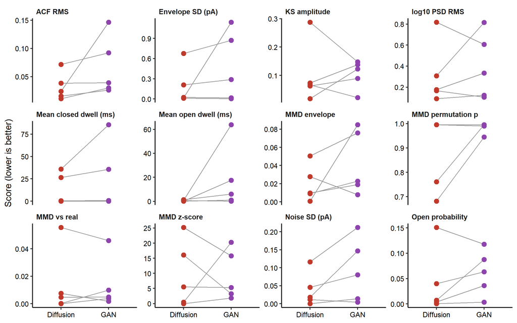

```r
pairable <- scored |>
  dplyr::filter(method %in% c("Diffusion", "GAN")) |>
  dplyr::group_by(metric, phenotype) |>
  dplyr::filter(dplyr::n_distinct(method) == 2) |>
  dplyr::ungroup()

n_ph <- dplyr::n_distinct(pairable$phenotype)

p_slope <- ggplot(pairable, aes(factor(method, levels = c("Diffusion", "GAN")),
                                score, group = phenotype)) +
  geom_line(colour = "grey60", linewidth = 0.4) +
  geom_point(aes(colour = method), size = 2.2) +
  facet_wrap(~ metric, scales = "free_y") +
  scale_colour_manual(values = pal, guide = "none") +
  labs(x = NULL, y = "Score (lower is better)")+
  theme_channel()
p_slope
```

```r
save_fig(p_slope, "fig_paired_metrics", width = 9, height = 6.5)
```

Each line is one phenotype. Lines that all slope the same way are the reportable result; lines that cross mean the ranking depends on which recording you happen to analyse.

```r
wide <- pairable |>
  dplyr::select(metric, phenotype, better, method, score) |>
  tidyr::pivot_wider(names_from = method, values_from = score) |>
  dplyr::mutate(diff = Diffusion - GAN)

paired_stats <- wide |>
  dplyr::group_by(metric, better) |>
  dplyr::summarise(
    n              = dplyr::n(),
    n_ties         = sum(diff == 0),
    median_diff    = median(diff),
    mean_diff      = mean(diff),
    sd_diff        = sd(diff),
    n_favour_diff  = sum(if (dplyr::first(better) == "lower") diff < 0 else diff > 0),
    p_paired_t     = if (dplyr::n() > 2 && sd(diff) > 0)
                       stats::t.test(diff)$p.value else NA_real_,
    ci_lo          = if (dplyr::n() > 2 && sd(diff) > 0)
                       stats::t.test(diff)$conf.int[1] else NA_real_,
    ci_hi          = if (dplyr::n() > 2 && sd(diff) > 0)
                       stats::t.test(diff)$conf.int[2] else NA_real_,
    # The sign test must be taken in the same tail as `better`, and exact ties
    # are absence of evidence rather than evidence against: counting them as
    # unfavourable reported 0.0625 for a metric that was three-fifths tied.
    p_sign         = {
      fav <- if (dplyr::first(better) == "lower") sum(diff < 0) else sum(diff > 0)
      nz  <- sum(diff != 0)
      if (nz > 0) stats::binom.test(fav, nz)$p.value else NA_real_
    },
    .groups = "drop"
  ) |>
  dplyr::mutate(
    n_eff   = n - n_ties,
    verdict = dplyr::case_when(
      n_eff == 0             ~ "no separation: all differences exactly tied",
      n_favour_diff == n_eff ~ "consistent: Diffusion",
      n_favour_diff == 0     ~ "consistent: GAN",
      TRUE                   ~ "inconsistent across phenotypes"),
    verdict = dplyr::if_else(n_ties > 0 & n_eff > 0,
                             paste0(verdict, " (", n_ties, " tied)"), verdict)) |>
  dplyr::select(metric, better, n, n_ties, median_diff, mean_diff, sd_diff,
                n_favour_diff, p_paired_t, ci_lo, ci_hi, p_sign, verdict)

nice_kable(paired_stats, digits = 5,
             caption = paste("Pooled paired comparison, Diffusion minus",
                             "GAN within each phenotype. The t-test is on the",
                             "within-phenotype differences; the sign test excludes",
                             "exact ties, so with five records it cannot fall below",
                             "0.0625 and the unanimity count is the reportable",
                             "result."))
```

Pooled paired comparison, Diffusion minus GAN within each phenotype. The t-test is on the within-phenotype differences; the sign test excludes exact ties, so with five records it cannot fall below 0.0625 and the unanimity count is the reportable result.

| metric | better | n | n_ties | median_diff | mean_diff | sd_diff | n_favour_diff | p_paired_t | ci_lo | ci_hi | p_sign | verdict |
| --- | --- | --- | --- | --- | --- | --- | --- | --- | --- | --- | --- | --- |
| ACF RMS | lower | 5 | 0 | -0.01922 | -0.03474 | 0.04958 | 5 | 0.19223 | -0.09631 | 0.02682 | 0.0625 | consistent: Diffusion |
| Envelope SD (pA) | lower | 5 | 0 | -0.08169 | -0.27654 | 0.47985 | 3 | 0.26700 | -0.87236 | 0.31927 | 1.0000 | inconsistent across phenotypes |
| KS amplitude | lower | 5 | 0 | -0.02649 | -0.00233 | 0.09671 | 3 | 0.95963 | -0.12241 | 0.11775 | 1.0000 | inconsistent across phenotypes |
| MMD envelope | lower | 5 | 0 | -0.01365 | -0.02249 | 0.03816 | 4 | 0.25796 | -0.06987 | 0.02489 | 0.3750 | inconsistent across phenotypes |
| MMD permutation p | lower | 5 | 1 | 0.00000 | -0.09751 | 0.13848 | 2 | 0.19049 | -0.26946 | 0.07444 | 1.0000 | inconsistent across phenotypes (1 tied) |
| MMD vs real | lower | 5 | 0 | -0.00007 | 0.00037 | 0.00767 | 3 | 0.91841 | -0.00915 | 0.00990 | 1.0000 | inconsistent across phenotypes |
| MMD z-score | lower | 5 | 0 | 0.20614 | 0.14259 | 12.76371 | 2 | 0.98127 | -15.70565 | 15.99083 | 1.0000 | inconsistent across phenotypes |
| Mean closed dwell (ms) | lower | 5 | 0 | -0.28285 | -11.80649 | 21.40026 | 5 | 0.28487 | -38.37842 | 14.76544 | 0.0625 | consistent: Diffusion |
| Mean open dwell (ms) | lower | 5 | 0 | -4.51766 | -17.06694 | 26.62782 | 4 | 0.22509 | -50.12974 | 15.99586 | 0.3750 | inconsistent across phenotypes |
| Noise SD (pA) | lower | 5 | 0 | -0.03464 | -0.05335 | 0.05723 | 4 | 0.10553 | -0.12441 | 0.01772 | 0.3750 | inconsistent across phenotypes |
| Open probability | lower | 5 | 0 | -0.02330 | -0.02114 | 0.04150 | 4 | 0.31830 | -0.07267 | 0.03039 | 0.3750 | inconsistent across phenotypes |
| log10 PSD RMS | lower | 5 | 0 | -0.03185 | -0.08454 | 0.27135 | 3 | 0.52437 | -0.42147 | 0.25238 | 1.0000 | inconsistent across phenotypes |

```r
readr::write_csv(paired_stats, file.path(CFG$out_dir, "paired_summary.csv"))
```

## What this many phenotypes will and will not support

```r
min_p_sign <- min(1, 2 * 0.5^n_ph)
cat(sprintf("Phenotypes pooled: %d\n", n_ph))
```

```
## Phenotypes pooled: 5
```

```r
cat(sprintf("Smallest two-sided p a sign test can return here: %.4f\n", min_p_sign))
```

```
## Smallest two-sided p a sign test can return here: 0.0625
```

```r
if (min_p_sign > 0.05) {
  cat("\nThat is above 0.05, so no sign test on these data can reach significance,\n",
      "however large or however unanimous the effect. The same floor applies to the\n",
      "Wilcoxon signed-rank test at this n. The p_sign column above is therefore\n",
      "reported for completeness and should not be leaned on.\n",
      "\nWhat these data do support: the per-phenotype values, the direction, whether\n",
      "it is unanimous, and the paired t interval on the differences. Those are the\n",
      "defensible summaries at this sample size.\n", sep = "")
} else {
  cat("\nA sign test is at least capable of reaching p < 0.05 here.\n")
}
```

```
##
## That is above 0.05, so no sign test on these data can reach significance,
## however large or however unanimous the effect. The same floor applies to the
## Wilcoxon signed-rank test at this n. The p_sign column above is therefore
## reported for completeness and should not be leaned on.
##
## What these data do support: the per-phenotype values, the direction, whether
## it is unanimous, and the paired t interval on the differences. Those are the
## defensible summaries at this sample size.
```

```r
cat(sprintf("\nUnanimous metrics: %d of %d.\n",
            sum(paired_stats$verdict != "inconsistent across phenotypes"),
            nrow(paired_stats)))
```

```
##
## Unanimous metrics: 3 of 12.
```

The paired t-test above assumes the five differences are roughly normal, which five points cannot demonstrate. It is quoted as an effect estimate with an interval rather than as a hypothesis test, and the interval is wide by construction. A metric that comes out inconsistent is a finding in itself: it means the two methods are close enough that recording-specific detail decides the ranking.

# 6. Publication figures

## Figure: example traces

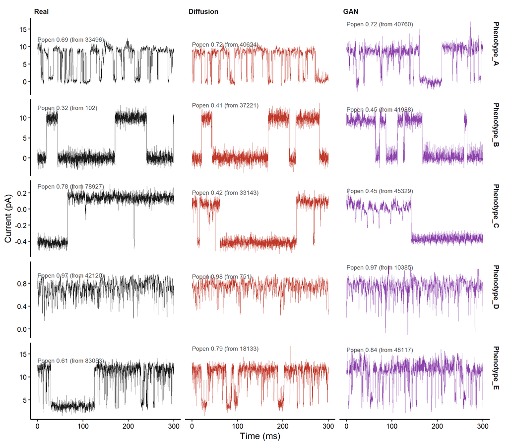

```r
traces <- pull_all("traces") |>
  dplyr::mutate(source = factor(source, levels = c("Real", "Diffusion", "GAN")))

# Popen of the window actually shown, so a panel cannot quietly misrepresent the
# record it came from.
win_lab <- traces |>
  dplyr::group_by(phenotype, source) |>
  dplyr::summarise(win_popen = dplyr::first(win_popen),
                   win_start = dplyr::first(win_start),
                   x = min(time_ms), y = max(current), .groups = "drop") |>
  dplyr::mutate(label = sprintf("Popen %.2f (from %d)", win_popen, win_start))

p_traces <- ggplot(traces, aes(time_ms, current, colour = source)) +
  geom_line(linewidth = 0.2) +
  geom_text(data = win_lab, aes(x, y, label = label), hjust = 0, vjust = 1,
            size = 2.4, colour = "grey30", inherit.aes = FALSE) +
  facet_grid(phenotype ~ source, scales = "free_y") +
  scale_colour_manual(values = pal, guide = "none") +
  labs(x = "Time (ms)", y = "Current (pA)") +
  theme_channel()
p_traces
```

```r
save_fig(p_traces, "fig_traces", width = 8, height = 1.4 * n_ph + 1)
```

The window is chosen by the same rule the Python previews use, so a panel shows gating rather than whichever stretch the file happens to start with. Where no window falls inside the target band — Phenotype_B is too quiet, Phenotype_D too busy — the nearest available is used, and its Popen is printed so the gap is visible rather than implied.

## Figure: idealisations

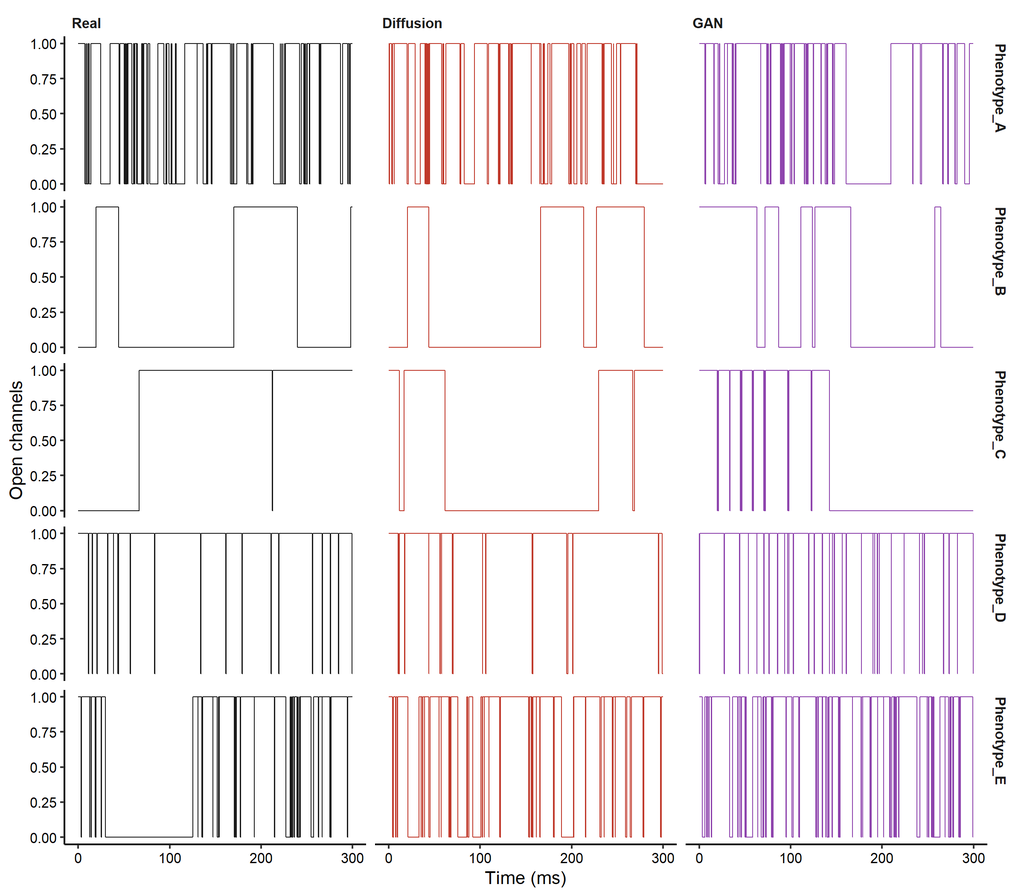

```r
p_ideal <- ggplot(traces, aes(time_ms, channels, colour = source)) +
  geom_step(linewidth = 0.3) +
  facet_grid(phenotype ~ source) +
  scale_colour_manual(values = pal, guide = "none") +
  labs(x = "Time (ms)", y = "Open channels") +
  theme_channel()
p_ideal
```

```r
save_fig(p_ideal, "fig_idealisations", width = 8, height = 1.2 * n_ph + 1)
```

## Figure: all-points amplitude histograms

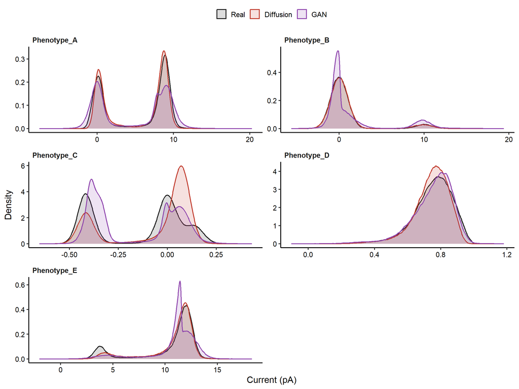

```r
p_amp <- pull_all("amp") |>
  dplyr::mutate(source = factor(source, levels = c("Real", "Diffusion", "GAN"))) |>
  ggplot(aes(current, colour = source, fill = source)) +
  geom_density(alpha = 0.15, linewidth = 0.5, adjust = 0.6) +
  facet_wrap(~ phenotype, scales = "free", ncol = 2) +
  scale_colour_manual(values = pal) + scale_fill_manual(values = pal) +
  labs(x = "Current (pA)", y = "Density") +
  theme_channel()
p_amp
```

```r
save_fig(p_amp, "fig_amplitude", width = 8, height = 2.2 * ceiling(n_ph / 2) + 1)
```

## Figure: single-level noise

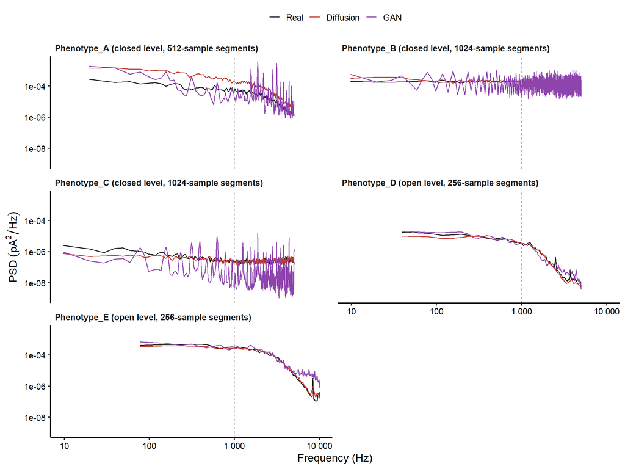

```r
# Panels are labelled with the level they were computed at, so the legend can
# state it and a phenotype that offers no baseline is not silently different.
panel_label <- setNames(sprintf("%s (%s level, %d-sample segments)",
                                names(LEVEL_OF), LEVEL_OF,
                                NPERSEG_OF[names(LEVEL_OF)]),
                        names(LEVEL_OF))

p_psd <- pull_all("psd") |>
  dplyr::mutate(source = factor(source, levels = c("Real", "Diffusion", "GAN")),
                phenotype = panel_label[phenotype]) |>
  ggplot(aes(freq, psd, colour = source)) +
  geom_line(linewidth = 0.4) +
  geom_vline(xintercept = CFG$filter_hz, linetype = "dashed",
             colour = "grey60", linewidth = 0.3) +
  facet_wrap(~ phenotype, ncol = 2) +
  scale_x_log10(labels = scales::label_number()) +
  scale_y_log10(labels = scales::label_scientific()) +
  scale_colour_manual(values = pal) +
  labs(x = "Frequency (Hz)", y = expression(PSD~(pA^2/Hz))) +
  theme_channel()

p_acf <- pull_all("acf") |>
  dplyr::mutate(source = factor(source, levels = c("Real", "Diffusion", "GAN")),
                phenotype = panel_label[phenotype]) |>
  ggplot(aes(lag_ms, acf, colour = source)) +
  geom_hline(yintercept = 0, colour = "grey70", linewidth = 0.3) +
  geom_line(linewidth = 0.4) +
  facet_wrap(~ phenotype, ncol = 2) +
  scale_colour_manual(values = pal) +
  labs(x = "Lag (ms)", y = "Autocorrelation") +
  theme_channel()

p_psd
```

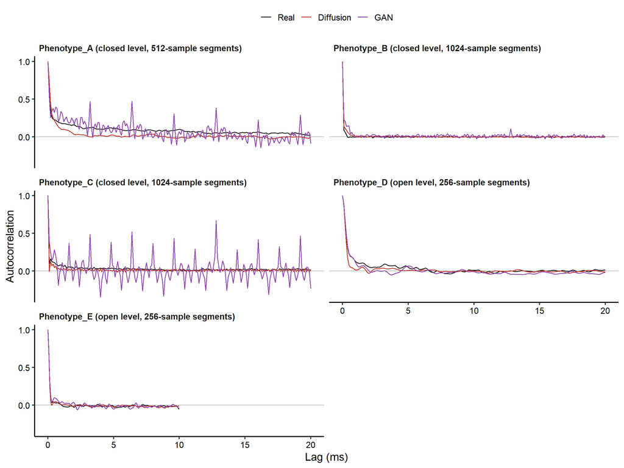

```r
p_acf
```

```r
save_fig(p_psd, "fig_psd", width = 8, height = 2.2 * ceiling(n_ph / 2) + 1)
save_fig(p_acf, "fig_acf", width = 8, height = 2.2 * ceiling(n_ph / 2) + 1)
```

## Figure: dwell times

Sigworth-Sine display: log abscissa, square-root ordinate. The diffusion arm’s `Channels` column is the conditioning idealisation it was handed, so it is a known ground truth. The GAN emitted its own labels, so those are a network output. They are plotted together for comparison and must not be described as equivalent in the manuscript.

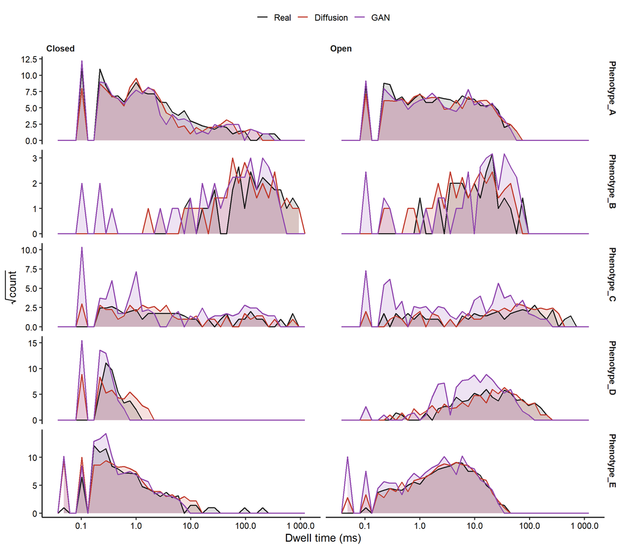

```r
p_dwell <- pull_all("dwell") |>
  dplyr::filter(dwell_ms > 0) |>
  dplyr::mutate(source = factor(source, levels = c("Real", "Diffusion", "GAN"))) |>
  ggplot(aes(dwell_ms, colour = source)) +
  geom_area(aes(y = after_stat(sqrt(count)), fill = source),
            stat = "bin", bins = 40, alpha = 0.15,
            position = "identity", colour = NA) +
  geom_freqpoly(aes(y = after_stat(sqrt(count))), bins = 40, linewidth = 0.45) +
  facet_grid(phenotype ~ state, scales = "free_y") +
  scale_x_log10(labels = scales::label_number()) +
  scale_colour_manual(values = pal) +
  scale_fill_manual(values = pal, guide = "none") +
  labs(x = "Dwell time (ms)", y = expression(sqrt(count))) +
  theme_channel()
p_dwell
```

```r
save_fig(p_dwell, "fig_dwell", width = 8, height = 1.5 * n_ph + 1)
```

and bars

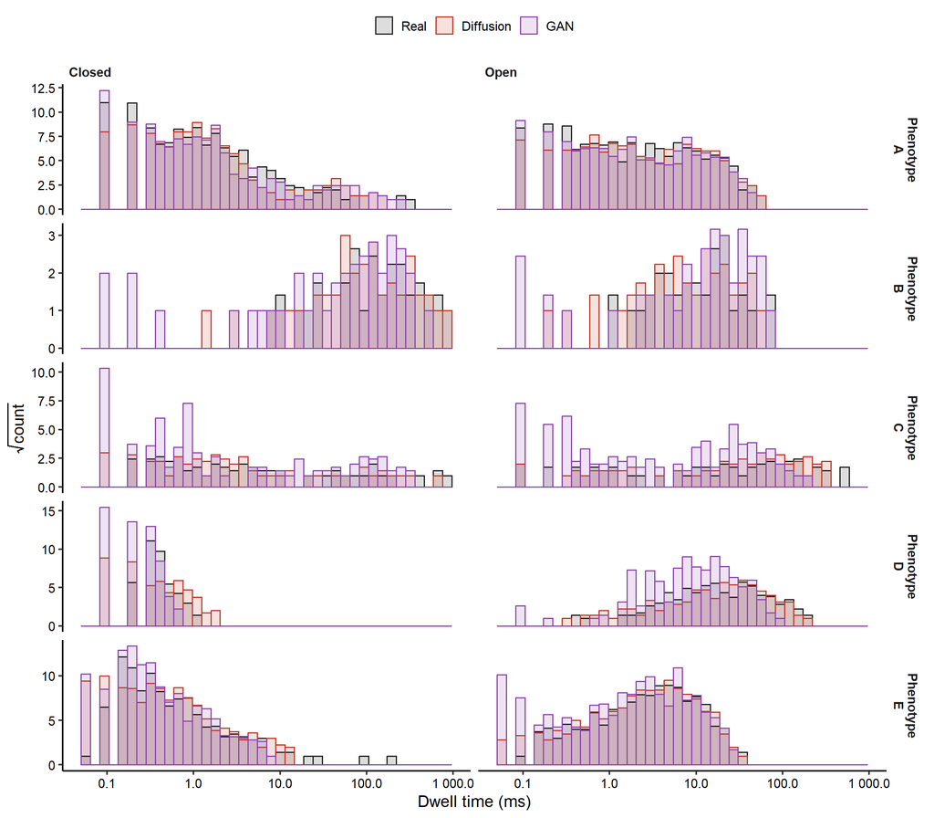

```r
d_dwell <- pull_all("dwell") |>
  dplyr::filter(dwell_ms > 0) |>
  dplyr::mutate(source = factor(source, levels = c("Real", "Diffusion", "GAN")))

# Log-spaced breaks, so every bar is the same width on the log axis. Equal
# linear bins would be wide at short dwells and thin at long ones.
brk <- 10^seq(log10(min(d_dwell$dwell_ms)), log10(max(d_dwell$dwell_ms)),
              length.out = 41)

p_dwell <- ggplot(d_dwell, aes(dwell_ms, colour = source)) +
  geom_histogram(aes(y = after_stat(sqrt(count)), fill = source),
                 breaks = brk, alpha = 0.15, position = "identity", colour = NA) +
  geom_histogram(aes(y = after_stat(sqrt(count))), fill = NA,
                 breaks = brk, linewidth = 0.4, position = "identity") +
  facet_grid(phenotype ~ state,
             scales = "free_y",
             labeller = labeller(
             phenotype = function(x) gsub("_", "\n", x, fixed = TRUE)
    )) +
  scale_x_log10(labels = scales::label_number()) +
  scale_colour_manual(values = pal) +
  scale_fill_manual(values = pal, guide = "none") +
  labs(x = "Dwell time (ms)", y = expression(sqrt(count))) +
  theme_channel()+
  theme(
    strip.text.y = element_text(
      angle = 270,
      hjust = 0.5,
      vjust = 0.5
    )
  ) +
    guides(colour = guide_legend(override.aes = list(
    fill = scales::alpha(pal[c("Real", "Diffusion", "GAN")], 0.15),
    linewidth = 0.4)))
p_dwell
```

```r
save_fig(p_dwell, "fig_dwell", width = 8, height = 1.5 * n_ph + 1)
```

## Bursts

```r
# Two-component exponential mixture on the closed times by EM, then the
# Colquhoun-Sakmann equal-areas tcrit: the gap length at which as many brief
# closures are misread as between-burst as long ones are misread as within.
fit_tcrit <- function(closed_ms, n_iter = 200) {
  x <- closed_ms[is.finite(closed_ms) & closed_ms > 0]
  if (length(x) < 50) return(NA_real_)
  tau <- stats::quantile(x, c(0.25, 0.9), names = FALSE)
  if (!(tau[2] > tau[1])) return(NA_real_)
  a <- c(0.5, 0.5)
  for (i in seq_len(n_iter)) {
    d1 <- a[1] * stats::dexp(x, 1 / tau[1])
    d2 <- a[2] * stats::dexp(x, 1 / tau[2])
    w  <- d1 / (d1 + d2); w[!is.finite(w)] <- 0.5
    a   <- c(mean(w), 1 - mean(w))
    tau <- c(sum(w * x) / sum(w), sum((1 - w) * x) / sum(1 - w))
    if (any(!is.finite(tau)) || any(tau <= 0)) return(NA_real_)
  }
  o <- order(tau); tau <- tau[o]; a <- a[o]
  # A record with one closed component has no bursts to find, and forcing a
  # tcrit onto it invents them.
  if (tau[2] / tau[1] < 3 || min(a) < 0.02) return(NA_real_)
  f <- function(t) a[1] * exp(-t / tau[1]) - a[2] * (1 - exp(-t / tau[2]))
  lo <- tau[1] * 1e-3; hi <- tau[2]
  if (!is.finite(f(lo)) || !is.finite(f(hi)) || f(lo) * f(hi) > 0) return(NA_real_)
  stats::uniroot(f, c(lo, hi), tol = 1e-9)$root
}

burst_of <- function(dw, tcrit) {
  if (!is.finite(tcrit)) return(NULL)
  sep <- dw$state == "Closed" & dw$dwell_ms >= tcrit
  b   <- cumsum(sep)
  d <- dw[!sep, , drop = FALSE]; b <- b[!sep]
  if (!nrow(d)) return(NULL)
  # The first and last bursts are cut off by the ends of the record, so both
  # would drag the mean burst length down.
  inner <- b > min(b) & b < max(b)
  d <- d[inner, , drop = FALSE]; b <- b[inner]
  if (!nrow(d)) return(NULL)
  tibble::tibble(burst = b, state = d$state, ms = d$dwell_ms) |>
    dplyr::group_by(burst) |>
    dplyr::summarise(length_ms = sum(ms),
                     n_open    = sum(state == "Open"),
                     open_ms   = sum(ms[state == "Open"]),
                     n_gap     = sum(state == "Closed"),
                     gap_ms    = sum(ms[state == "Closed"]),
                     .groups = "drop") |>
    dplyr::filter(n_open > 0)
}

res_burst <- purrr::map(manifest$phenotype, function(ph) {
  arms <- recs[[ph]]; fs <- FS_MAIN[[ph]]
  dwl <- lapply(names(arms), function(a) dwell_times(arms[[a]]$channels, fs[[a]]))
  names(dwl) <- names(arms)
  # One tcrit per phenotype, taken from the real record and imposed on every
  # arm. Per-arm tcrits would make the burst counts incomparable.
  tcrit <- fit_tcrit(dwl$Real$dwell_ms[dwl$Real$state == "Closed"])
  per_burst <- purrr::map_dfr(names(arms), function(a) {
    b <- burst_of(dwl[[a]], tcrit)
    if (is.null(b) || !nrow(b)) return(NULL)
    dplyr::mutate(b, phenotype = ph, source = a)
  })
  if (!nrow(per_burst)) return(list(summary = NULL, per_burst = NULL))
  list(
    per_burst = per_burst,
    summary = per_burst |>
      dplyr::group_by(phenotype, source) |>
      dplyr::summarise(
        tcrit_ms = tcrit, n_bursts = dplyr::n(),
        `Burst length (ms)`       = mean(length_ms),
        `Openings per burst`      = mean(n_open),
        `Open time in burst (ms)` = sum(open_ms) / sum(n_open),
        `Gap in burst (ms)`       = if (sum(n_gap)) sum(gap_ms) / sum(n_gap) else NA_real_,
        `Burst Popen`             = sum(open_ms) / sum(length_ms),
        .groups = "drop") |>
      dplyr::mutate(`Bursts per s` = purrr::map_dbl(source, function(a)
        sum(per_burst$source == a) / (nrow(arms[[a]]) / fs[[a]]))))
})

burst      <- purrr::map_dfr(res_burst, "summary")
bursts_raw <- purrr::map_dfr(res_burst, "per_burst")

nice_kable(dplyr::select(burst, phenotype, source, tcrit_ms, n_bursts,
                           dplyr::everything()), digits = 4,
             caption = paste("Burst kinetics. tcrit is fitted on the",
                             "real record of each phenotype and applied to all",
                             "three arms; a phenotype whose closed times are",
                             "monoexponential yields no tcrit and drops out."))
```

Burst kinetics. tcrit is fitted on the real record of each phenotype and applied to all three arms; a phenotype whose closed times are monoexponential yields no tcrit and drops out.

| phenotype | source | tcrit_ms | n_bursts | Burst length (ms) | Openings per burst | Open time in burst (ms) | Gap in burst (ms) | Burst Popen | Bursts per s |
| --- | --- | --- | --- | --- | --- | --- | --- | --- | --- |
| Phenotype_A | Diffusion | 4.2582 | 62 | 78.9032 | 12.4194 | 5.4114 | 1.0243 | 0.8518 | 8.4565 |
| Phenotype_A | GAN | 4.2582 | 79 | 54.1696 | 9.7595 | 4.8442 | 0.7868 | 0.8728 | 10.7753 |
| Phenotype_A | Real | 4.2582 | 88 | 56.6080 | 10.1250 | 4.7424 | 0.9415 | 0.8482 | 12.0028 |
| Phenotype_C | Diffusion | 7.8043 | 15 | 484.2067 | 6.0667 | 78.6407 | 1.4053 | 0.9853 | 1.5000 |
| Phenotype_C | GAN | 7.8043 | 47 | 97.1149 | 5.9574 | 15.8129 | 0.5871 | 0.9700 | 4.7000 |
| Phenotype_C | Real | 7.8043 | 17 | 356.0647 | 4.0588 | 86.4014 | 1.7577 | 0.9849 | 1.7000 |
| Phenotype_E | Diffusion | 2.0843 | 71 | 64.7042 | 12.3803 | 4.8287 | 0.4327 | 0.9239 | 14.2000 |
| Phenotype_E | GAN | 2.0843 | 42 | 113.7774 | 27.1429 | 3.8190 | 0.3871 | 0.9111 | 8.4000 |
| Phenotype_E | Real | 2.0843 | 55 | 74.7109 | 14.2000 | 4.8590 | 0.4328 | 0.9235 | 11.0000 |

```r
burst_cmp <- burst |>
  dplyr::select(-tcrit_ms, -n_bursts) |>
  tidyr::pivot_longer(-c(phenotype, source), names_to = "metric") |>
  tidyr::pivot_wider(names_from = source, values_from = value) |>
  dplyr::filter(is.finite(Real), is.finite(Diffusion), is.finite(GAN)) |>
  dplyr::mutate(err_diffusion = abs(Diffusion - Real),
                err_gan       = abs(GAN - Real),
                favours = dplyr::case_when(
  err_diffusion < err_gan ~ "Diffusion",
  err_gan < err_diffusion ~ "GAN",
  TRUE                    ~ "Tie"
  ))

nice_kable(burst_cmp, digits = 4,
             caption = "Burst metrics, absolute error against the real record.")
```

Burst metrics, absolute error against the real record.

| phenotype | metric | Diffusion | GAN | Real | err_diffusion | err_gan | favours |
| --- | --- | --- | --- | --- | --- | --- | --- |
| Phenotype_A | Burst length (ms) | 78.9032 | 54.1696 | 56.6080 | 22.2953 | 2.4383 | GAN |
| Phenotype_A | Openings per burst | 12.4194 | 9.7595 | 10.1250 | 2.2944 | 0.3655 | GAN |
| Phenotype_A | Open time in burst (ms) | 5.4114 | 4.8442 | 4.7424 | 0.6690 | 0.1018 | GAN |
| Phenotype_A | Gap in burst (ms) | 1.0243 | 0.7868 | 0.9415 | 0.0828 | 0.1546 | Diffusion |
| Phenotype_A | Burst Popen | 0.8518 | 0.8728 | 0.8482 | 0.0035 | 0.0245 | Diffusion |
| Phenotype_A | Bursts per s | 8.4565 | 10.7753 | 12.0028 | 3.5463 | 1.2276 | GAN |
| Phenotype_C | Burst length (ms) | 484.2067 | 97.1149 | 356.0647 | 128.1420 | 258.9498 | Diffusion |
| Phenotype_C | Openings per burst | 6.0667 | 5.9574 | 4.0588 | 2.0078 | 1.8986 | GAN |
| Phenotype_C | Open time in burst (ms) | 78.6407 | 15.8129 | 86.4014 | 7.7608 | 70.5886 | Diffusion |
| Phenotype_C | Gap in burst (ms) | 1.4053 | 0.5871 | 1.7577 | 0.3524 | 1.1706 | Diffusion |
| Phenotype_C | Burst Popen | 0.9853 | 0.9700 | 0.9849 | 0.0004 | 0.0149 | Diffusion |
| Phenotype_C | Bursts per s | 1.5000 | 4.7000 | 1.7000 | 0.2000 | 3.0000 | Diffusion |
| Phenotype_E | Burst length (ms) | 64.7042 | 113.7774 | 74.7109 | 10.0067 | 39.0665 | Diffusion |
| Phenotype_E | Openings per burst | 12.3803 | 27.1429 | 14.2000 | 1.8197 | 12.9429 | Diffusion |
| Phenotype_E | Open time in burst (ms) | 4.8287 | 3.8190 | 4.8590 | 0.0304 | 1.0400 | Diffusion |
| Phenotype_E | Gap in burst (ms) | 0.4327 | 0.3871 | 0.4328 | 0.0001 | 0.0457 | Diffusion |
| Phenotype_E | Burst Popen | 0.9239 | 0.9111 | 0.9235 | 0.0004 | 0.0125 | Diffusion |
| Phenotype_E | Bursts per s | 14.2000 | 8.4000 | 11.0000 | 3.2000 | 2.6000 | GAN |

```r
nice_kable(
  burst_cmp |>
    dplyr::group_by(metric) |>
    dplyr::summarise(n = dplyr::n(),
                     n_favour_diffusion = sum(favours == "Diffusion"),
                     .groups = "drop"),
  caption = "Unanimity of the burst metrics across phenotypes.")
```

Unanimity of the burst metrics across phenotypes.

| metric | n | n_favour_diffusion |
| --- | --- | --- |
| Burst Popen | 3 | 3 |
| Burst length (ms) | 3 | 2 |
| Bursts per s | 3 | 1 |
| Gap in burst (ms) | 3 | 3 |
| Open time in burst (ms) | 3 | 2 |
| Openings per burst | 3 | 1 |

```r
readr::write_csv(burst,     file.path(CFG$out_dir, "burst_kinetics.csv"))
readr::write_csv(burst_cmp, file.path(CFG$out_dir, "burst_comparison.csv"))
```

## Burst Figures

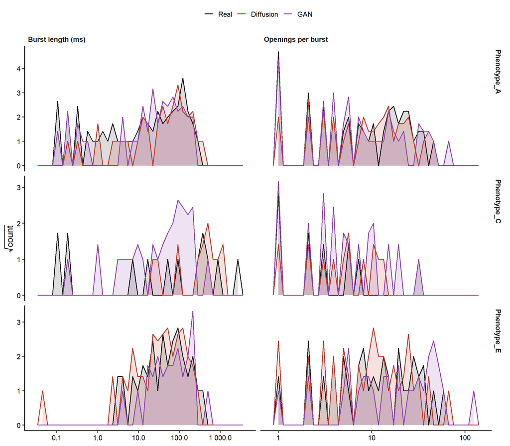

```r
p_burst <- bursts_raw |>
  dplyr::transmute(phenotype, source,
                   `Burst length (ms)` = length_ms,
                   `Openings per burst` = as.numeric(n_open)) |>
  tidyr::pivot_longer(-c(phenotype, source), names_to = "quantity") |>
  dplyr::filter(value > 0) |>
  dplyr::mutate(source = factor(source, levels = c("Real", "Diffusion", "GAN"))) |>
  ggplot(aes(value, colour = source)) +
  geom_area(aes(y = after_stat(sqrt(count)), fill = source),
            stat = "bin", bins = 40, alpha = 0.15,
            position = "identity", colour = NA) +
  geom_freqpoly(aes(y = after_stat(sqrt(count))), bins = 40, linewidth = 0.5) +
  facet_grid(phenotype ~ quantity, scales = "free") +
  scale_x_log10(labels = scales::label_number()) +
  scale_colour_manual(values = pal) +
  scale_fill_manual(values = pal, guide = "none") +
  labs(x = NULL, y = expression(sqrt(count))) +
  theme_channel()
p_burst
```

```r
save_fig(p_burst, "fig_burst", width = 8, height = 1.5 * n_ph + 1)
readr::write_csv(bursts_raw, file.path(CFG$out_dir, "bursts_per_burst.csv"))
```

bars

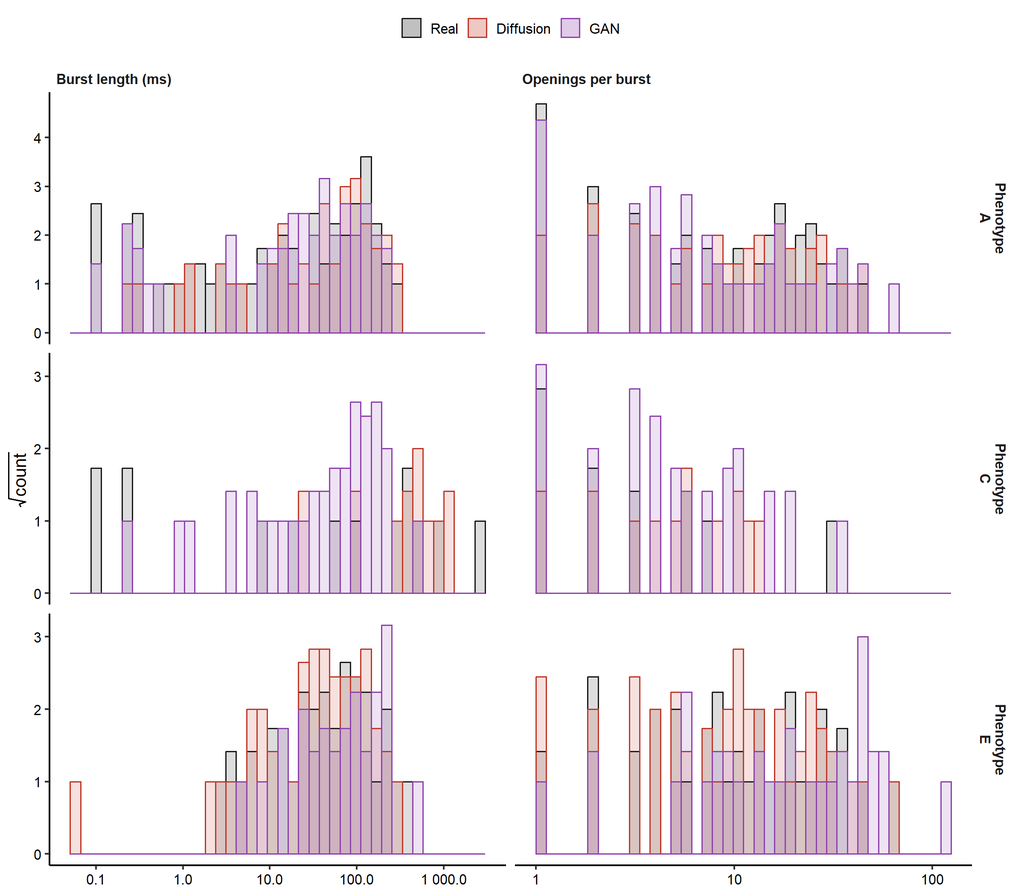

```r
d_burst <- bursts_raw |>
  dplyr::transmute(phenotype, source,
                   `Burst length (ms)` = length_ms,
                   `Openings per burst` = as.numeric(n_open)) |>
  tidyr::pivot_longer(-c(phenotype, source), names_to = "quantity") |>
  dplyr::filter(value > 0) |>
  dplyr::mutate(source = factor(source, levels = c("Real", "Diffusion", "GAN")))

# Breaks per quantity, since burst length and opening count span quite
# different ranges, and log-spaced so every bar is one width on the log axis.
log_breaks <- function(v, n = 41) {
  r <- range(v)
  if (r[1] == r[2]) return(NULL)
  10^seq(log10(r[1]), log10(r[2]), length.out = n)
}
brk_burst <- split(d_burst$value, d_burst$quantity) |> lapply(log_breaks)

layer_hist <- function(q) {
  d <- dplyr::filter(d_burst, quantity == q)
  list(
    geom_histogram(data = d, aes(y = after_stat(sqrt(count)), fill = source),
                   breaks = brk_burst[[q]], alpha = 0.15,
                   position = "identity", colour = NA),
    geom_histogram(data = d, aes(y = after_stat(sqrt(count))), fill = NA,
                   breaks = brk_burst[[q]], linewidth = 0.4,
                   position = "identity")
  )
}


p_burst <- ggplot(d_burst, aes(value, colour = source)) +
  lapply(names(brk_burst), layer_hist) +
  facet_grid(
    phenotype ~ quantity,
    scales = "free",
    labeller = labeller(
      phenotype = function(x) gsub("_", "\n", x, fixed = TRUE)
    )
  ) +
  scale_x_log10(labels = scales::label_number()) +
  scale_colour_manual(values = pal) +
  scale_fill_manual(values = pal, guide = "none") +
  labs(
    x = NULL,
    y = expression(sqrt(count))
  ) +
  theme_channel() +
  theme(
    strip.text.y = element_text(
      angle = 270,
      hjust = 0.5,
      vjust = 0.5
    )
  ) +
  guides(
    colour = guide_legend(
      override.aes = list(
        fill = scales::alpha(
          pal[c("Real", "Diffusion", "GAN")],
          0.15
        ),
        linewidth = 0.4
      )
    )
  )


p_burst
```

```r
save_fig(p_burst, "fig_burst", width = 8, height = 1.5 * n_ph + 1)
readr::write_csv(bursts_raw, file.path(CFG$out_dir, "bursts_per_burst.csv"))
```

## Label self-consistency

Carried over from `DiffuChannel_analysis.Rmd`, where it ran on one record at a time. Each arm’s current trace is idealised on its own, with a conventional half-amplitude criterion and no reference to any other arm, and the result is compared against the `Channels` column that arm shipped with.

This asks a different question from everything above. The GAN emitted its labels and its trace together, so there is no external truth to score them against – but there is an internal one: the labels should agree with what the arm’s own current is doing. The diffusion arm was handed its labels before it started, so its agreement measures whether the generated current followed the conditioning it was given. The real record supplies the floor, because expert idealisation and a half-amplitude criterion do not agree perfectly either, and an arm cannot reasonably be asked to do better than the seed.

```r
res_selfcon <- purrr::map(manifest$phenotype, function(ph) {

  arms <- recs[[ph]]
  fs   <- FS_MAIN[[ph]]

  # First pass: try unsupervised EM on every arm.
  em_rec <- purrr::map(names(arms), function(a) {

    d <- arms[[a]]

    n_lev <- max(
      1,
      max(d$channels, na.rm = TRUE)
    )

    idealise_half_amplitude(
      d$current,
      n_levels = n_lev,
      polarity = POL_MAIN[[ph]]
    )
  })

  names(em_rec) <- names(arms)

  # If EM fails for any arm, use label-anchored CV for every
  # arm in this phenotype, keeping the comparison consistent.
  em_failed <- vapply(
    em_rec,
    function(x) all(is.na(x)),
    logical(1)
  )

  phenotype_fallback <- any(em_failed)

  if (phenotype_fallback) {
    failed_arms <- names(arms)[em_failed]

    method_note <- paste0(
      "Phenotype-wide fallback because unsupervised EM failed for: ",
      paste(failed_arms, collapse = ", ")
    )
  } else {
    method_note <- ""
  }

  # Second pass: calculate self-consistency using the method
  # selected for this entire phenotype.
  out <- purrr::map(names(arms), function(a) {

    d <- arms[[a]]

    n_lev <- max(
      1,
      max(d$channels, na.rm = TRUE)
    )

    lab <- d$channels > 0

    if (phenotype_fallback) {

      rec <- idealise_label_anchored_cv(
        current = d$current,
        labels = d$channels,
        n_levels = n_lev,
        polarity = POL_MAIN[[ph]],
        block_len = 1000L,
        trim = 0.10,
        min_state_n = 50L
      )

      ideal_method <- "Phenotype-wide label-anchored CV fallback"

    } else {

      rec <- em_rec[[a]]
      ideal_method <- "Unsupervised EM"
    }

    # This occurs only if the selected phenotype-wide
    # method still fails for this arm.
    if (all(is.na(rec))) {

      failure_reason <- attr(rec, "why")

      if (is.null(failure_reason)) {
        failure_reason <- "no reason was recorded"
      }

      return(list(
        summary = tibble::tibble(
          phenotype = ph,
          source = a,
          kappa = NA_real_,
          f1_open = NA_real_,
          popen_labels = mean(lab),
          popen_recovered = NA_real_,
          open_ms_labels = NA_real_,
          open_ms_recovered = NA_real_,
          flicker = NA,
          ideal_method = ideal_method,
          note = paste(
            method_note,
            "Selected method failed:",
            failure_reason
          )
        ),
        dwell = NULL
      ))
    }

    op <- rec > 0

    tp <- sum(lab & op)
    fp <- sum(!lab & op)
    fn <- sum(lab & !op)

    dl <- dwell_times(
      as.integer(lab),
      fs[[a]]
    )

    dr <- dwell_times(
      as.integer(op),
      fs[[a]]
    )

    mo <- function(x) {

      v <- x$dwell_ms[x$state == "Open"]

      if (length(v)) {
        mean(v)
      } else {
        NA_real_
      }
    }

    list(
      summary = tibble::tibble(
        phenotype = ph,
        source = a,
        kappa = cohen_kappa(lab, op),
        f1_open = if (2 * tp + fp + fn > 0) {
          2 * tp / (2 * tp + fp + fn)
        } else {
          NA_real_
        },
        popen_labels = mean(lab),
        popen_recovered = mean(op),
        open_ms_labels = mo(dl),
        open_ms_recovered = mo(dr),
        flicker = length(rle(op)$lengths) > 0.5 * length(op),
        ideal_method = ideal_method,
        note = method_note
      ),

      dwell = dplyr::bind_rows(
        dplyr::mutate(
          dl,
          origin = "Own labels"
        ),
        dplyr::mutate(
          dr,
          origin = "Recovered from current"
        )
      ) |>
        dplyr::mutate(
          phenotype = ph,
          source = a
        )
    )
  })

  list(
    summary = purrr::map_dfr(out, "summary"),
    dwell   = purrr::map_dfr(out, "dwell")
  )
})

self_consist <- purrr::map_dfr(res_selfcon, "summary")
sc_dwell     <- purrr::map_dfr(res_selfcon, "dwell")

if (any(self_consist$flicker %in% TRUE)) {
  warning("The recovered idealisation switches on more than half the samples ",
          "in: ", paste(sprintf("%s/%s", self_consist$phenotype[self_consist$flicker %in% TRUE],
                                self_consist$source[self_consist$flicker %in% TRUE]),
                        collapse = ", "),
          ". That is a wrong level estimate rather than a fast record, and the ",
          "kappa for those rows means nothing. Check the amplitude histogram.")
}

# A recovered Popen that is the complement of the labelled one is an inverted
# idealisation, not a disagreement, and its kappa is the negative of the real
# number. It should not happen now the polarity is imposed, so say so loudly.
inverted <- self_consist |>
  dplyr::filter(is.finite(kappa),
                abs(popen_recovered - (1 - popen_labels)) < 0.05,
                kappa < 0)
if (nrow(inverted)) {
  warning("The idealisation looks inverted in: ",
          paste(sprintf("%s/%s", inverted$phenotype, inverted$source),
                collapse = ", "), ". Check POL_MAIN for those phenotypes.")
}

nice_kable(self_consist, digits = 4,
             caption = paste("Label self-consistency. Each arm's",
                             "Channels column against a half-amplitude",
                             "idealisation of that same arm's current. The real",
                             "record is the floor, not a target of 1."))
```

Label self-consistency. Each arm’s Channels column against a half-amplitude idealisation of that same arm’s current. The real record is the floor, not a target of 1.

| phenotype | source | kappa | f1_open | popen_labels | popen_recovered | open_ms_labels | open_ms_recovered | flicker | ideal_method | note |
| --- | --- | --- | --- | --- | --- | --- | --- | --- | --- | --- |
| Phenotype_A | Real | 0.9500 | 0.9792 | 0.5825 | 0.5871 | 4.7505 | 4.9588 | FALSE | Unsupervised EM |  |
| Phenotype_A | Diffusion | 0.9502 | 0.9791 | 0.5784 | 0.5831 | 5.4371 | 4.7289 | FALSE | Unsupervised EM |  |
| Phenotype_A | GAN | 0.9519 | 0.9783 | 0.5461 | 0.5506 | 4.9070 | 6.1074 | FALSE | Unsupervised EM |  |
| Phenotype_B | Real | 0.9723 | 0.9743 | 0.0715 | 0.0715 | 15.5522 | 15.5522 | FALSE | Unsupervised EM |  |
| Phenotype_B | Diffusion | 0.9319 | 0.9371 | 0.0790 | 0.0761 | 14.1071 | 10.8757 | FALSE | Unsupervised EM |  |
| Phenotype_B | GAN | 0.9620 | 0.9680 | 0.1592 | 0.1592 | 21.5149 | 10.1433 | FALSE | Unsupervised EM |  |
| Phenotype_C | Real | 0.9935 | 0.9974 | 0.6037 | 0.6006 | 79.4382 | 25.3426 | FALSE | Unsupervised EM |  |
| Phenotype_C | Diffusion | 0.9627 | 0.9906 | 0.7548 | 0.7407 | 78.6260 | 8.4173 | FALSE | Unsupervised EM |  |
| Phenotype_C | GAN | 0.9810 | 0.9903 | 0.4858 | 0.4915 | 15.6190 | 21.7482 | FALSE | Unsupervised EM |  |
| Phenotype_D | Real | 0.3454 | 0.9783 | 0.9883 | 0.9462 | 31.8800 | 5.5629 | FALSE | Phenotype-wide label-anchored CV fallback | Phenotype-wide fallback because unsupervised EM failed for: Real |
| Phenotype_D | Diffusion | 0.3405 | 0.9771 | 0.9879 | 0.9437 | 32.0744 | 5.2054 | FALSE | Phenotype-wide label-anchored CV fallback | Phenotype-wide fallback because unsupervised EM failed for: Real |
| Phenotype_D | GAN | 0.3298 | 0.9726 | 0.9849 | 0.9345 | 14.3362 | 4.5810 | FALSE | Phenotype-wide label-anchored CV fallback | Phenotype-wide fallback because unsupervised EM failed for: Real |
| Phenotype_E | Real | 0.9434 | 0.9898 | 0.8171 | 0.8226 | 4.8987 | 4.2535 | FALSE | Unsupervised EM |  |
| Phenotype_E | Diffusion | 0.9149 | 0.9880 | 0.8571 | 0.8598 | 4.8150 | 3.7976 | FALSE | Unsupervised EM |  |
| Phenotype_E | GAN | 0.8529 | 0.9827 | 0.8804 | 0.8850 | 3.8244 | 4.6237 | FALSE | Unsupervised EM |  |

```r
sc_cmp <- self_consist |>
  dplyr::select(phenotype, source, kappa) |>
  tidyr::pivot_wider(names_from = source, values_from = kappa) |>
  dplyr::filter(
    is.finite(Real),
    is.finite(Diffusion),
    is.finite(GAN)
  ) |>
  dplyr::mutate(
  deficit_diffusion = Real - Diffusion,
  deficit_gan       = Real - GAN,

  error_diffusion = abs(Diffusion - Real),
  error_gan       = abs(GAN - Real),

  pct_error_diffusion = 100 * error_diffusion / abs(Real),
  pct_error_gan       = 100 * error_gan / abs(Real),

  favours = dplyr::case_when(
    error_diffusion < error_gan ~ "Diffusion",
    error_gan < error_diffusion ~ "GAN",
    TRUE                        ~ "Tie"
  )
)

nice_kable(sc_cmp, digits = 4,
             caption = paste("Shortfall in kappa against the real",
                             "record's own floor. A negative deficit means the",
                             "arm's labels agree with its current better than",
                             "the expert idealisation agrees with the seed,",
                             "which is a sign the arm is too clean rather than",
                             "a sign it is good."))
```

Shortfall in kappa against the real record’s own floor. A negative deficit means the arm’s labels agree with its current better than the expert idealisation agrees with the seed, which is a sign the arm is too clean rather than a sign it is good.

| phenotype | Real | Diffusion | GAN | deficit_diffusion | deficit_gan | error_diffusion | error_gan | pct_error_diffusion | pct_error_gan | favours |
| --- | --- | --- | --- | --- | --- | --- | --- | --- | --- | --- |
| Phenotype_A | 0.9500 | 0.9502 | 0.9519 | -0.0002 | -0.0020 | 0.0002 | 0.0020 | 0.0233 | 0.2074 | Diffusion |
| Phenotype_B | 0.9723 | 0.9319 | 0.9620 | 0.0404 | 0.0103 | 0.0404 | 0.0103 | 4.1584 | 1.0613 | GAN |
| Phenotype_C | 0.9935 | 0.9627 | 0.9810 | 0.0308 | 0.0125 | 0.0308 | 0.0125 | 3.1012 | 1.2599 | GAN |
| Phenotype_D | 0.3454 | 0.3405 | 0.3298 | 0.0050 | 0.0156 | 0.0050 | 0.0156 | 1.4367 | 4.5141 | Diffusion |
| Phenotype_E | 0.9434 | 0.9149 | 0.8529 | 0.0285 | 0.0905 | 0.0285 | 0.0905 | 3.0183 | 9.5933 | Diffusion |

```r
cat(sprintf("\nPhenotypes where the diffusion arm is the more self-consistent: %d of %d.\n",
            sum(sc_cmp$favours == "Diffusion"), nrow(sc_cmp)))
```

```
##
## Phenotypes where the diffusion arm is the more self-consistent: 3 of 5.
```

```r
readr::write_csv(self_consist, file.path(CFG$out_dir, "self_consistency.csv"))
readr::write_csv(sc_cmp, file.path(CFG$out_dir, "self_consistency_comparison.csv"))
```

The gap between the two dwell distributions below is the missed-event loss: the brief openings and closures that a half-amplitude criterion cannot recover from the current, however good the trace is. Being able to measure it at all is what having the conditioning idealisation buys.

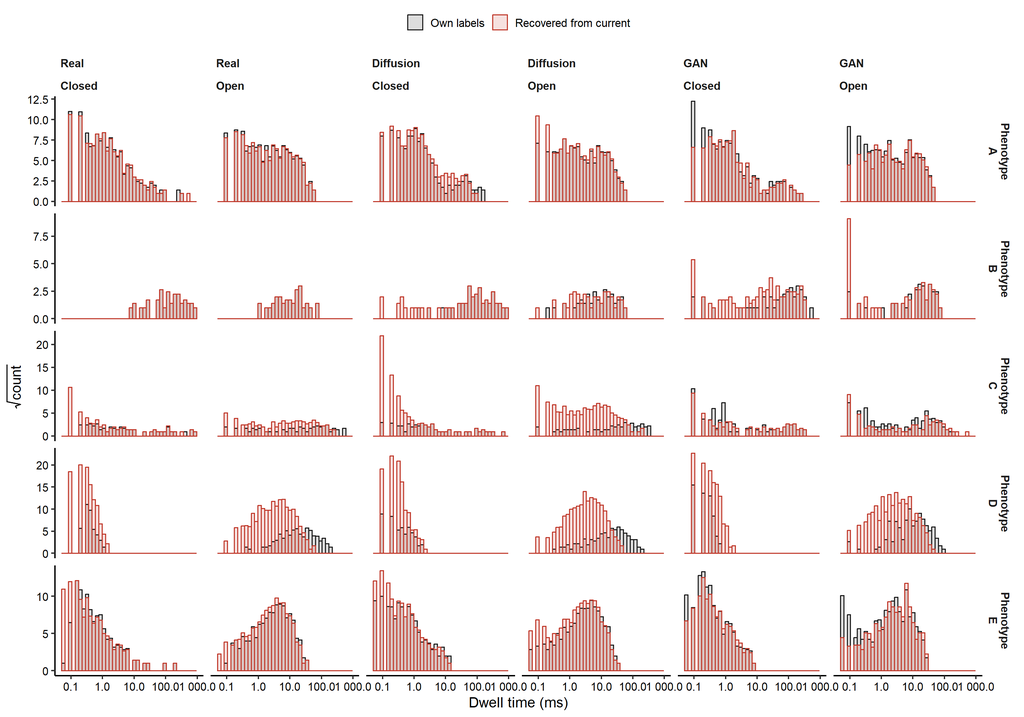

```r
pal_origin <- c("Own labels" = "#1b1b1b",
                "Recovered from current" = "#c0392b")

d_sc <- sc_dwell |>
  dplyr::filter(dwell_ms > 0) |>
  dplyr::mutate(source = factor(source, levels = c("Real", "Diffusion", "GAN")),
                origin = factor(origin, levels = names(pal_origin)))

brk_sc <- 10^seq(log10(min(d_sc$dwell_ms)), log10(max(d_sc$dwell_ms)),
                 length.out = 41)

p_selfcon <- ggplot(d_sc, aes(dwell_ms, colour = origin)) +
  geom_histogram(aes(y = after_stat(sqrt(count)), fill = origin),
                 breaks = brk_sc, alpha = 0.15, position = "identity",
                 colour = NA) +
  geom_histogram(aes(y = after_stat(sqrt(count))), fill = NA,
                 breaks = brk_sc, linewidth = 0.4, position = "identity") +
  facet_grid(
    phenotype ~ source + state,
    scales = "free_y",
    labeller = labeller(
      phenotype = function(x) gsub("_", "\n", x, fixed = TRUE)
    )
  ) +
  scale_x_log10(labels = scales::label_number()) +
  scale_colour_manual(values = pal_origin) +
  scale_fill_manual(values = pal_origin, guide = "none") +
  labs(x = "Dwell time (ms)", y = expression(sqrt(count))) +
  theme_channel() +
  theme(
    strip.text.y = element_text(
      angle = 270,
      hjust = 0.5,
      vjust = 0.5
    )
  ) +
  guides(
    colour = guide_legend(
      override.aes = list(
        fill = scales::alpha(pal_origin, 0.15),
        linewidth = 0.4
      )
    )
  )

p_selfcon
```

```r
save_fig(p_selfcon, "fig_self_consistency", width = 10, height = 1.5 * n_ph + 1)
readr::write_csv(sc_dwell, file.path(CFG$out_dir, "self_consistency_dwells.csv"))
```

## Figure: slow envelope

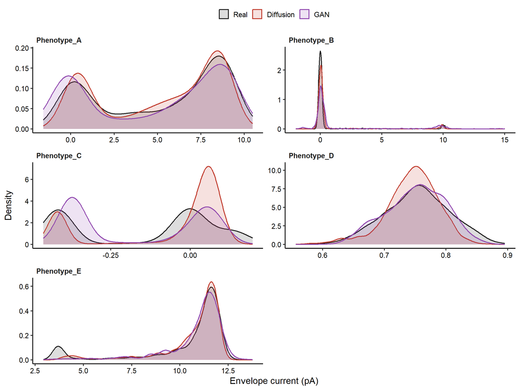

```r
p_env <- pull_all("env") |>
  dplyr::mutate(source = factor(source, levels = c("Real", "Diffusion", "GAN"))) |>
  ggplot(aes(value, colour = source, fill = source)) +
  geom_density(alpha = 0.15, linewidth = 0.5) +
  facet_wrap(~ phenotype, scales = "free", ncol = 2) +
  scale_colour_manual(values = pal) + scale_fill_manual(values = pal) +
  labs(x = "Envelope current (pA)", y = "Density") +
  theme_channel()
p_env
```

```r
save_fig(p_env, "fig_envelope", width = 8, height = 2.2 * ceiling(n_ph / 2) + 1)
```

## Figure: manifold projections (optional)

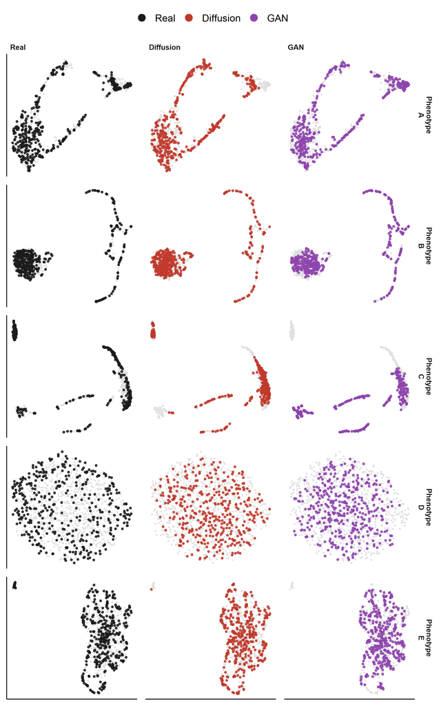

```r
if (!all(vapply(c("uwot", "Rtsne"), requireNamespace, logical(1), quietly = TRUE))) {
  stop("Set CFG$do_manifold = FALSE or install uwot and Rtsne.")
}

proj <- purrr::map_dfr(seq_len(nrow(manifest)), function(i) {
  row <- manifest[i, ]
  d <- list(Real = read_record(row$raw), Diffusion = read_record(row$ddpm))
  if (!is.na(row$gan)) d$GAN <- read_record(row$gan)
  Wp <- lapply(d, function(x) make_windows(x$current, CFG$proj_win, CFG$n_windows_proj))
  X <- do.call(rbind, Wp)
  lab <- rep(names(Wp), vapply(Wp, nrow, integer(1)))
  X <- scale(X); X[!is.finite(X)] <- 0
  um <- uwot::umap(X, n_neighbors = 15, min_dist = 0.1, n_components = 2)
  ts <- Rtsne::Rtsne(X, dims = 2, perplexity = 30, check_duplicates = FALSE,
                     pca = TRUE)$Y
  dplyr::bind_rows(
    tibble::tibble(x = um[, 1], y = um[, 2], source = lab, method = "UMAP"),
    tibble::tibble(x = ts[, 1], y = ts[, 2], source = lab, method = "t-SNE")
  ) |> dplyr::mutate(phenotype = row$phenotype)
})

proj <- proj |>
  dplyr::mutate(source = factor(source, levels = c("Real", "Diffusion", "GAN"))) |>
  dplyr::group_by(phenotype, method) |>
  dplyr::mutate(x = scales::rescale(x), y = scales::rescale(y)) |>
  dplyr::ungroup()

# One arm per column, over a grey ghost of the full cloud so each panel still
# shows where the other two sat. Rescaling per phenotype lets the three columns
# share fixed scales, which free scales previously prevented.
plot_proj <- function(d) {
  ggplot(d, aes(x, y)) +
    geom_point(
      data = dplyr::select(d, -source),
      colour = "grey88",
      size = 0.7
    ) +
    geom_point(
      aes(colour = source),
      size = 1.1,
      alpha = 0.85
    ) +
    facet_grid(
      phenotype ~ source,
      labeller = labeller(
        phenotype = function(x) gsub("_", "\n", x)
      )
    ) +
    scale_colour_manual(values = pal) +
    guides(
      colour = guide_legend(
        override.aes = list(size = 4, alpha = 1)
      )
    ) +
    labs(x = NULL, y = NULL) +
    theme_channel(base_size = 11) +
    theme(
      axis.text = element_blank(),
      axis.ticks = element_blank(),
      legend.text = element_text(size = 12),
      legend.key.size = unit(1.5, "lines"),
      panel.spacing = unit(0.7, "lines"),
      strip.text.y = element_text(
        angle = 270,
        hjust = 0.5,
        vjust = 0.5
      )
    )
}
p_proj_umap <- plot_proj(dplyr::filter(proj, method == "UMAP"))
p_proj_tsne <- plot_proj(dplyr::filter(proj, method == "t-SNE"))
p_proj_umap
```

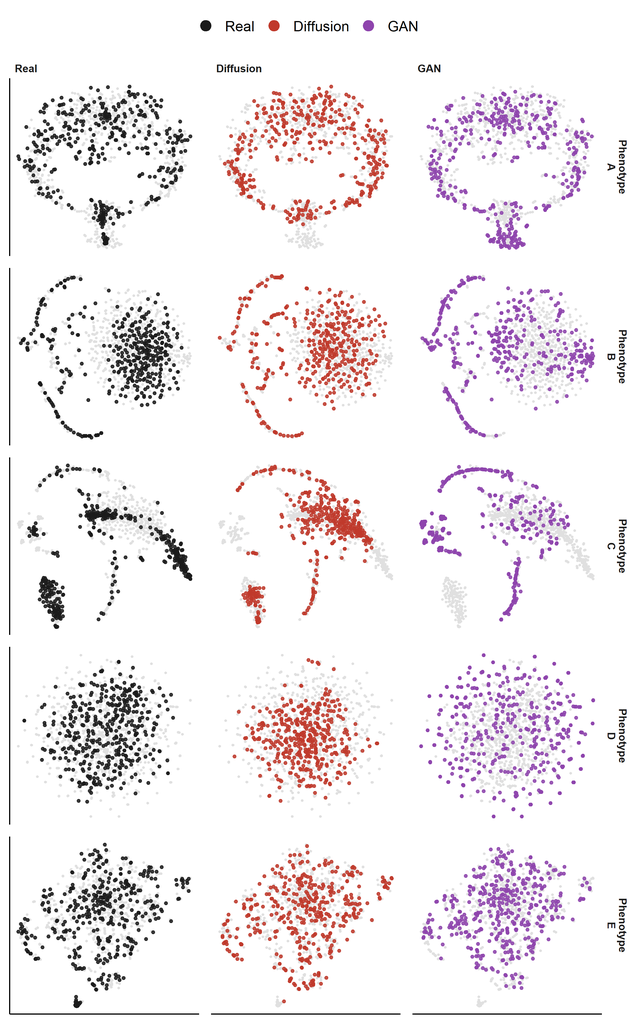

```r
p_proj_tsne
```

```r
save_fig(p_proj_umap, "fig_manifold_umap", width = 7.5, height = 2.3 * n_ph + 1)
save_fig(p_proj_tsne, "fig_manifold_tsne", width = 7.5, height = 2.3 * n_ph + 1)
readr::write_csv(proj, file.path(CFG$out_dir, "manifold_coordinates.csv"))
```

# 7. Numbers for the manuscript

Rows keyed to `[[placeholder]]` names. Pooled values are medians across phenotypes, with the range, because five records do not support a mean and an interval being read as an estimate.

```r
fmt <- function(x, d = 4) formatC(x, digits = d, format = "g")

pooled <- scored |>
  dplyr::group_by(metric, method) |>
  dplyr::summarise(median = median(value), lo = min(value), hi = max(value),
                   .groups = "drop")

placeholders <- dplyr::bind_rows(
  tibble::tibble(placeholder = "n_phenotypes", value = as.character(n_ph),
                 note = "paired seed records"),
  tibble::tibble(placeholder = "n_samples_total",
                 value = format(sum(info$n_real), big.mark = ","),
                 note = "seed samples across all phenotypes"),
  # Rate before unique, or floating-point dust splits one rate into several.
  tibble::tibble(placeholder = "sample_khz",
                 value = paste(unique(round(sort(info$fs_real) / 1000, 3)),
                               collapse = ", "),
                 note = "acquisition rate(s), kHz"),
  pooled |>
    dplyr::transmute(
      placeholder = paste0(gsub("[^A-Za-z0-9]+", "_", tolower(metric)), "_",
                           tolower(method)),
      value = sprintf("%s (%s to %s)", fmt(median), fmt(lo), fmt(hi)),
      note = paste("median across phenotypes, range in brackets")),
  paired_stats |>
    dplyr::transmute(
      placeholder = paste0("unanimity_", gsub("[^A-Za-z0-9]+", "_", tolower(metric))),
      value = sprintf("%d/%d favour Diffusion", n_favour_diff, n),
      note = verdict)
)

nice_kable(placeholders, caption = "Values keyed to the manuscript placeholders.")
```

Values keyed to the manuscript placeholders.

| placeholder | value | note |
| --- | --- | --- |
| n_phenotypes | 5 | paired seed records |
| n_samples_total | 473,316 | seed samples across all phenotypes |
| sample_khz | 10, 20 | acquisition rate(s), kHz |
| acf_rms_diffusion | 0.02409 (0.01095 to 0.07173) | median across phenotypes, range in brackets |
| acf_rms_gan | 0.03908 (0.0263 to 0.1464) | median across phenotypes, range in brackets |
| envelope_sd_pa__diffusion | 1.728 (0.04299 to 3.431) | median across phenotypes, range in brackets |
| envelope_sd_pa__gan | 1.535 (0.04825 to 3.928) | median across phenotypes, range in brackets |
| ks_amplitude_diffusion | 0.06675 (0.01806 to 0.2876) | median across phenotypes, range in brackets |
| ks_amplitude_gan | 0.123 (0.02207 to 0.1478) | median across phenotypes, range in brackets |
| mmd_envelope_diffusion | 0.009693 (0.0007693 to 0.05061) | median across phenotypes, range in brackets |
| mmd_envelope_gan | 0.02272 (0.007959 to 0.08477) | median across phenotypes, range in brackets |
| mmd_permutation_p_diffusion | 0.004975 (0.004975 to 0.3184) | median across phenotypes, range in brackets |
| mmd_permutation_p_gan | 0.00995 (0.004975 to 0.05473) | median across phenotypes, range in brackets |
| mmd_vs_real_diffusion | 0.004778 (-1.502e-05 to 0.0556) | median across phenotypes, range in brackets |
| mmd_vs_real_gan | 0.004848 (0.001752 to 0.04598) | median across phenotypes, range in brackets |
| mmd_z_score_diffusion | 5.543 (-0.05501 to 25.24) | median across phenotypes, range in brackets |
| mmd_z_score_gan | 5.336 (1.796 to 20.31) | median across phenotypes, range in brackets |
| mean_closed_dwell_ms__diffusion | 3.957 (0.3932 to 161.6) | median across phenotypes, range in brackets |
| mean_closed_dwell_ms__gan | 4.083 (0.2201 to 112.1) | median across phenotypes, range in brackets |
| mean_open_dwell_ms__diffusion | 14.11 (4.815 to 78.63) | median across phenotypes, range in brackets |
| mean_open_dwell_ms__gan | 14.34 (3.824 to 21.51) | median across phenotypes, range in brackets |
| noise_sd_pa__diffusion | 0.999 (0.04066 to 1.392) | median across phenotypes, range in brackets |
| noise_sd_pa__gan | 1.164 (0.05438 to 1.519) | median across phenotypes, range in brackets |
| open_probability_diffusion | 0.7548 (0.079 to 0.9879) | median across phenotypes, range in brackets |
| open_probability_gan | 0.5461 (0.1592 to 0.9849) | median across phenotypes, range in brackets |
| log10_psd_rms_diffusion | 0.1763 (0.09052 to 0.8171) | median across phenotypes, range in brackets |
| log10_psd_rms_gan | 0.3331 (0.105 to 0.8146) | median across phenotypes, range in brackets |
| unanimity_acf_rms | 5/5 favour Diffusion | consistent: Diffusion |
| unanimity_envelope_sd_pa_ | 3/5 favour Diffusion | inconsistent across phenotypes |
| unanimity_ks_amplitude | 3/5 favour Diffusion | inconsistent across phenotypes |
| unanimity_mmd_envelope | 4/5 favour Diffusion | inconsistent across phenotypes |
| unanimity_mmd_permutation_p | 2/5 favour Diffusion | inconsistent across phenotypes (1 tied) |
| unanimity_mmd_vs_real | 3/5 favour Diffusion | inconsistent across phenotypes |
| unanimity_mmd_z_score | 2/5 favour Diffusion | inconsistent across phenotypes |
| unanimity_mean_closed_dwell_ms_ | 5/5 favour Diffusion | consistent: Diffusion |
| unanimity_mean_open_dwell_ms_ | 4/5 favour Diffusion | inconsistent across phenotypes |
| unanimity_noise_sd_pa_ | 4/5 favour Diffusion | inconsistent across phenotypes |
| unanimity_open_probability | 4/5 favour Diffusion | inconsistent across phenotypes |
| unanimity_log10_psd_rms | 3/5 favour Diffusion | inconsistent across phenotypes |

## What this comparison does and does not settle

Both methods are scored identically above, so the numbers are comparable as measures of how much the synthetic data resemble the real record. That is the only question they answer.

They do not settle the question the paper is about. The GAN emits its raw trace and its `Channels` column together, so its labels are a network output; the diffusion pipeline is handed its labels before it starts and never touches them. A GAN record could match the real data better on every metric here and still be the less useful training set, because a downstream idealiser trained against it is being scored on another network’s opinion rather than on truth. If the GAN wins on similarity, say so plainly and make the ground-truth argument on its own terms.